# Lab 8 SSF Clogit models

4/10/2017 updated with new prepare_ssf_steps function from Dan

## WILD 562 Wildlife Habitat Modeling

### MArk Hebblewhite, 4/4/17

### Lab 8: Step Selection Functions (SSF) and conditional Logistic regression models

#### Objectives

##### 1. Extract movement summary data from GPS data using R movement analysis tools.

##### 2. Build a spatial used-available dataset based on movement parameters for one elk, yl29, from Banff National Park.

##### 3. Introduce matched-case control or conditional logistic regression with the elk yl29 dataset, and learn about the different interpretations of clogit and logit models.

##### 4. Introduce the analysis of mixed-effects conditional logistic regression models with the R package mclogit.

#### 0.1 Preliminaries: setting packages (output supressed)

#### 0.2 Preliminaries: setting working directory

```r
##### 0.1 Preliminaries: setting working directory #######################################################################

## define working directory on each computer
wd_laptop <- "/Users/mark.hebblewhite/Dropbox/WILD 562/Spring2017/lab8/"
wd_desktop <- "/Users/mark.hebblewhite/Documents/Teaching/UofMcourses/WILD562/Spring2017/Labs/lab8/"

## automatically set working directory depending which computer you're on
ifelse(file.exists(wd_laptop), setwd(wd_laptop), setwd(wd_desktop))
```

```
## [1] "/Users/mark.hebblewhite/Dropbox/WILD 562/Spring2017/Lab8"
```

```r
getwd()
```

```
## [1] "/Users/mark.hebblewhite/Dropbox/WILD 562/Spring2017/Lab8"
```

```r
list.files() ## handy command to see what is inside the working directory
```

```
##  [1] "eliescode"
##  [2] "extra"
##  [3] "Lab8_4_10_17_ver2.r"
##  [4] "Lab8_4_10_17_ver3.r"
##  [5] "Lab8_4_10_17_ver4.r"
##  [6] "Lab8_4.10.17_Heb.R"
##  [7] "Lab8_4.4.17.R"
##  [8] "Lab8_4.5.17.R"
##  [9] "Lab8_clogitSSF_files"
## [10] "Lab8_clogitSSF.html"
## [11] "Lab8_clogitSSF.Rmd"
## [12] "Lab8.R"
## [13] "Lecture20_ConditionalLogisticRegression.pptx"
## [14] "prepare_ssf_burst_eacker.R"
## [15] "SSF"
## [16] "ssf_fun_2016_final.R"
## [17] "ssf_out.R"
## [18] "ssf_yl29_bursted_all3.tiff"
## [19] "WILD562-Lab8_Clogit_Models.docx"
## [20] "wolf_ssf_clogit.csv"
## [21] "working"
## [22] "yl29.csv"
```

#### Objective 1.0 Estimating Movement Parameters to Inform SSF sampling

##### First we will use a GPS data set from a single female elk, yl29 (yellow tag 29) from Ya Ha Tinda, the same dataset as Lab 7.

##### These data are based on: Hebblewhite, M., and E. H. Merrill. 2009. Trade-offs between predation risk and forage differ between migrant strategies in a migratory ungulate. Ecology 90:3445-3454.

```r
#the entire dataset

# read in csv file
yl29 <- read.csv("yl29.csv", header=T)

# inspect the dataset
head(yl29)
```

```
##   ID2 SORTID CollarBrand ELKUID     Date  Time   UTMX    UTMY
## 1 902      1        2200     29 05/02/03  0:00 603144 5734518
## 2 903      2        2200     29 05/02/03  2:00 603106 5734550
## 3 904      3        2200     29 05/02/03  4:00 603079 5734549
## 4 905      4        2200     29 05/02/03  6:02 603062 5734552
## 5 906      5        2200     29 05/02/03  8:00 603251 5734787
## 6 907      6        2200     29 05/02/03 10:00 603181 5734663
```

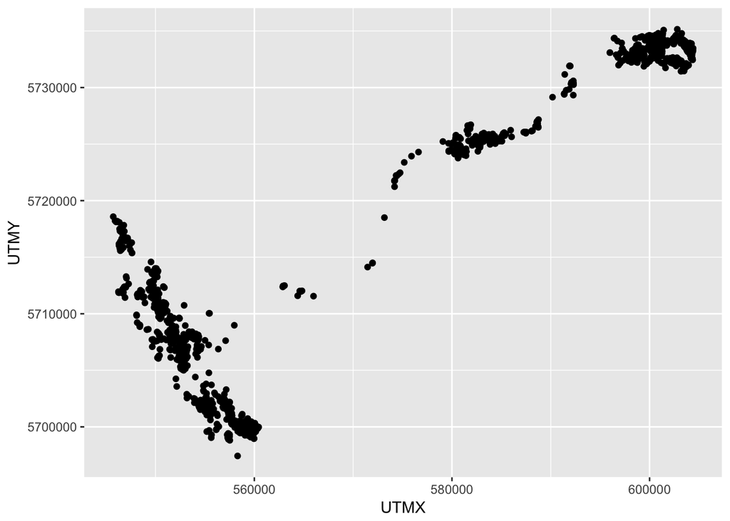

```r
## Plot the data
ggplot(yl29, aes(x=UTMX, y = UTMY)) + geom_point()
```

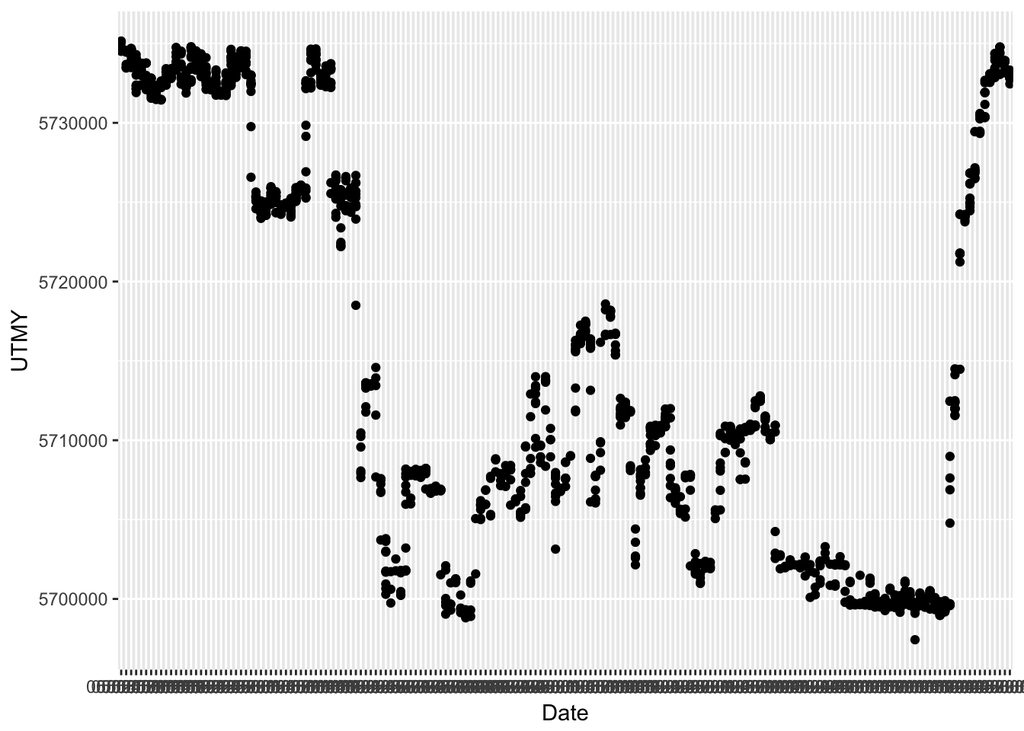

```r
ggplot(yl29, aes(x=Date, y= UTMY)) + geom_point()
```

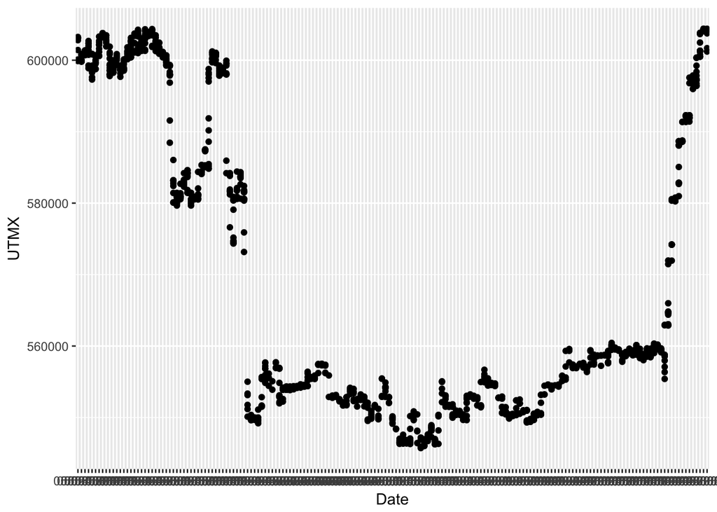

```r
ggplot(yl29, aes(x=Date, y= UTMX)) + geom_point()
```

```r
### What date did this elk migrate?
```

#### Objective 1.1 Load custom functions in ssf_fun_2016_final.R from BjÃ¶rn Reineking, and then convert yl29 data to a move object using the move package

##### ANIMOVE Course Instuctor http://animove.org/courses/2016-mpi/

```r
# load custom functions from BjÃ¶rn Reineking
source("ssf_fun_2016_final.R", verbose = FALSE)
```

#### Objective 1.2 Convert spatial data frame to a spatial move object using the R package move

##### Credit by citing the R package move for now

##### Bart Kranstauber and Marco Smolla (2016). move: Visualizing and Analyzing Animal Track Data. R package version 2.1.0. https://CRAN.R-project.org/package=move

# create “move” object using move package

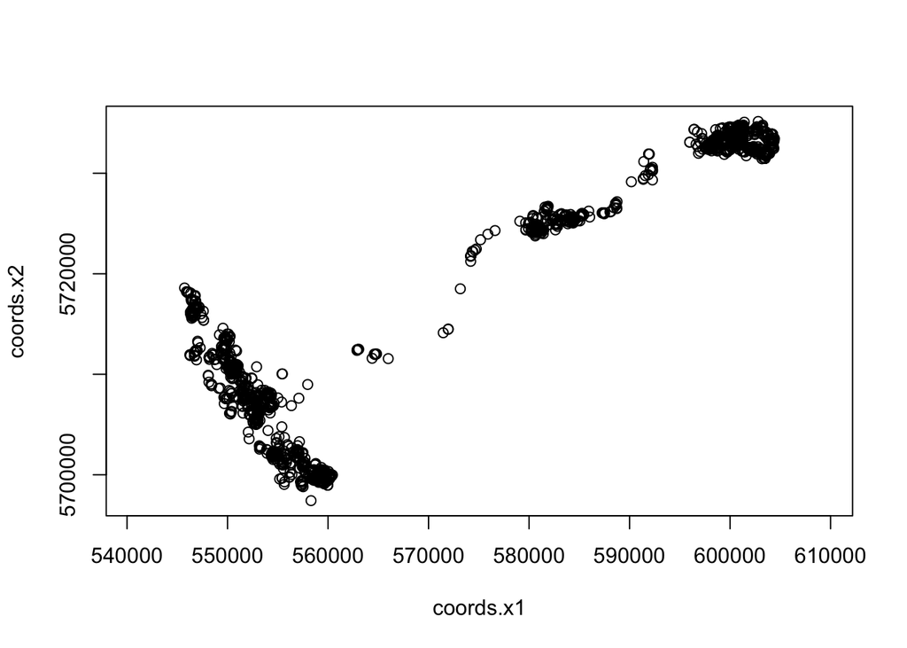

```r
# first format time stamp to bring date and time together

# format Date as date class
yl29$Date <- as.Date(yl29$Date, format="%m/%d/%y")

# make Time variable to standardize number of digits
yl29$Time <- as.character(yl29$Time)

new.time <- numeric(length(yl29$Time))

for(i in 1:length(yl29$Time)){
  if(nchar(substr(yl29$Time[i], 1, 5))==4) {new.time[i] <- paste("0",yl29$Time[i],sep="")}else
    if(nchar(substr(yl29$Time[i], 1, 5))==5) {new.time[i] <- yl29$Time[i]}
}

# now paste together Date and Time to make timestamp and convert to POSIXct format
yl29$rtime <- as.POSIXct(paste(yl29$Date,new.time, sep=" "),  format="%Y-%m-%d %H:%M", tz="America/Denver")

### Make the yl29 data a Move object or MoveStack (multiple Move objects, i.e., animals)
### ?move
yl29.mv <- move(x=yl29$UTMX, y=yl29$UTMY,
                time=yl29$rtime,
                data=yl29, proj=CRS("+proj=utm +zone=11 +datum=NAD83 +units=m +no_defs +ellps=GRS80 +towgs84=0,0,0"), animal=yl29$ELKUID)

# visualize the movement data
par(mfrow=c(1,1))
plot(yl29.mv) ## note you can do this with the Move Object
```

```r
# look at sumary of move object
summary(yl29.mv)
```

```
## $X29
##   TravDist  MaxDist  MinDist FarthDist AverDist   SDDist   SEDist
## 1 855677.4 21159.54 1.000273  61.23918 584.0801 1108.387 2.574963
##
## $X29
##     Duration  AverDur    SDDur  dupl multseason
## 1 4367 hours 2.980887 3.351075 FALSE      FALSE
##
## $X29
##    AverSpeed    VarSpeed MaxSpeed
## 1 0.05788835 0.008017326 0.845271
##
## $X29
##   AverAzimuth VarAzimuth SEAzimuth
## 1    6.453782  0.9831441 -130.6514
```

##### THIS PART OF THE ANALYSIS IS FOR THINNING THE DATA BASED ON A MAXIMUM TIME STEP AND CREATING A moveBurst object that can be used in a step selection function = we have modified some of the code Björn Reineking to make this work as his code only deals with “Move” or “MoveStack” objects

```r
# set maximum step duration
step <- 3

# burst track and create burstId variable with long (i.e., >=3 hour timelag) and normal (i.e., <3 hour timelag) segments
bursted<-move::burst(yl29.mv, c('normal','long')[1+(timeLag(yl29.mv, units='hours')>step)])

head(bursted@burstId)
```

```
## [1] normal normal normal normal normal normal
## Levels: long normal
```

```r
#[1] normal normal normal normal normal normal
#Levels: long normal
```

#### The projection seems to matter just slightly whether you work in UTMs or latlong, but the angles are the same when calculated

# bursted2 <- spTransform(bursted, CRS(“+proj=longlat +ellps=GRS80 +datum=NAD83 +towgs84=0,0,0”))

```r
# create empty list
burstlyl29 <- vector("list",(nrow(bursted)-1))

# create list of bursted segments (note you need two locations for this)
for(i in 2:nrow(bursted)){
  burstlyl29[[(i-1)]] <- bursted[(i-1):i]
}

# create empty index to hold indicator variable of whether a track was of normal or long timestep
# We use this to filter the data latter
index1 <- numeric(nrow(bursted)-1)

# loop over index1 using ifelse statements to create indicator variable
for(i in 1:(nrow(bursted)-1)){
  if(burstlyl29[[i]]@burstId=="normal"){index1[i] <- 1}else
    if(burstlyl29[[i]]@burstId=="long"){index1[i] <- 0}
}
```

##### Next we are going to calculate turning angles

```r
#This function seems correct (a negative of an angle should be the same
#radians as the positive of the angle just with an opposite sign.)
## The function is currently defined as
degrees2radians <- function (x)
{
  radians <- (x * (pi/180))
  return(radians)
}

# calculate distances and turn angles (relative as well in radians) for ALL data
dist <- distance(yl29.mv)
yl29.mv <- spTransform(yl29.mv, CRS = "+proj=longlat +ellps=GRS80 +datum=NAD83 +towgs84=0,0,0")
abs.angle <- angle(yl29.mv)
abs.angle3 <- degrees2radians(abs.angle)

# calculate turn angles by using diff function to find difference between consecutive angles
ta.data <- data.frame(index1, c(NA, diff(abs.angle3)))
names(ta.data) <- c("index1", "turn.angle3")

# set long bursts to NA using index1 created above where index1==0
for(i in 1:(length(ta.data$turn.angle3))){

  if(ta.data$index1[i]==0){ta.data$turn.angle3[i] <- NA}else
    if(ta.data$index1[i]==1){ta.data$turn.angle3[i] <- ta.data$turn.angle3[i]}

}

# set NA for turn angle for  after missing burst (the next turn angle cannot be calcuted with a missing before between it)
indext1 <- which(is.na(ta.data$turn.angle3)==T)+1
indext1 <- indext1[2:207]

#ta.data$turn.angle3[indext0] <- NA
ta.data$turn.angle3[indext1] <- NA

# put a place holder of 0 to hold first row of data
ta.data$turn.angle3[1] <- 0

# set distances to NA where turn angle is not available
ta.data$dist <- ifelse(is.na(ta.data$turn.angle3)==F,dist,NA)

# set absolute angles to NA where turn angle is not available
ta.data$abs.angle3 <- ifelse(is.na(ta.data$turn.angle3)==F,abs.angle3,NA)

# remove na's before fitting distributions to distances and relative turn angles
rel.angle3 <- ifelse(abs(na.omit(ta.data$turn.angle3)) > pi, sign(na.omit(ta.data$turn.angle3)) * (abs(na.omit(ta.data$turn.angle3)) - 2 * pi), na.omit(ta.data$turn.angle3))
dist <- na.omit(ta.data$dist)
abs.angle3 <- na.omit(ta.data$abs.angle3)
```

```r
angle_dist_summary <- data.frame(cbind(summary(dist), summary(rel.angle3)))
names(angle_dist_summary) <- c("distance", "relative angle (radians)")
angle_dist_summary
```

```
##         distance relative angle (radians)
## Min.        1.00                 -3.14100
## 1st Qu.    72.55                 -1.17000
## Median    192.60                  0.07343
## Mean      414.10                  0.11740
## 3rd Qu.   471.40                  1.52700
## Max.     6084.00                  3.13700
```

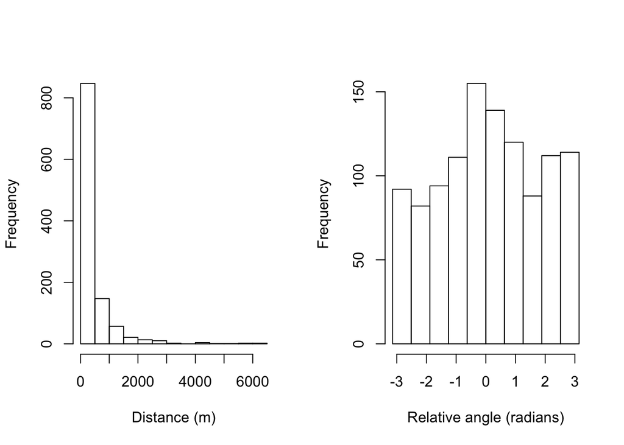

```r
# examine empirical distances and turning angles
par(mfrow = c(1, 2))
hist(dist, breaks = 20, main = "", xlab = "Distance (m)")
hist(rel.angle3, breaks = seq(-pi, pi,len=11), main="", xlab="Relative angle (radians)")
```

#### Now, following recent papers, instead of bootstrap sampling the observed/ empirical step length and turning angle distribution, we fit different shaped functions to the step lenght distribution and draw from that distribution.

```r
# Fit distributions to distances
fexp <- fitdistr(dist, "exponential")
fgam <- fitdistr(dist, "gamma")
flogn <- fitdistr(dist, "lognormal")

AICout <- AIC(flogn, fgam, fexp)
AICout <- cbind(AICout, c(0, diff(AICout$AIC)))
names(AICout) <- c("df", "AIC", "deltaAIC")
AICout
```

```
##       df      AIC  deltaAIC
## flogn  2 15380.24   0.00000
## fgam   2 15456.97  76.72989
## fexp   1 15557.74 100.76908
```

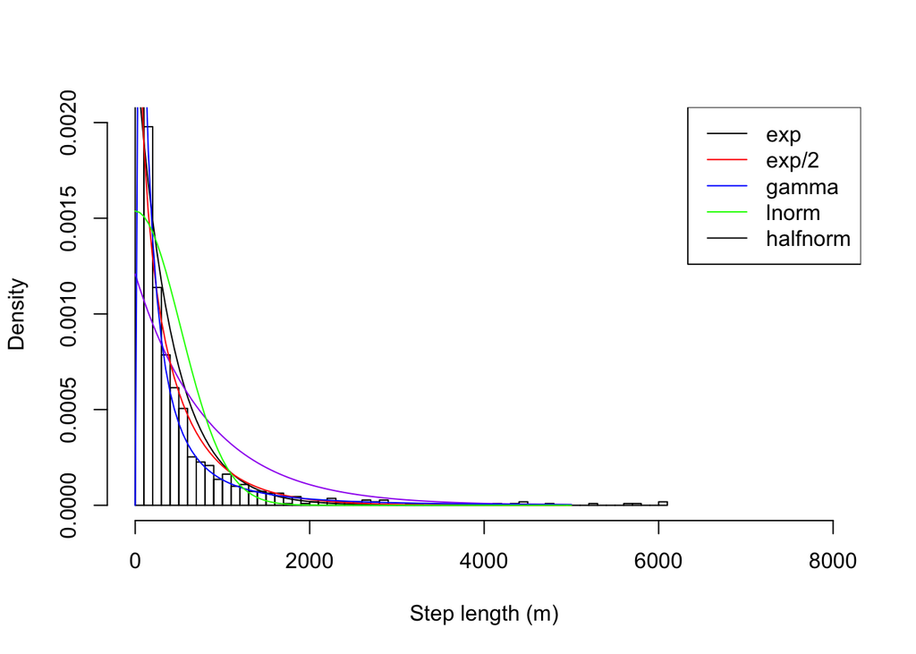

```r
## So logn seems to be the best fitting function

par(mfrow = c(1,1))
hist(dist, breaks = 50, prob = TRUE, xlim = c(0, 8000), ylim = c(0, 2e-3),xlab = "Step length (m)", main = "")
plot(function(x) dexp(x, rate = fexp$estimate), add = TRUE, from = 0, to = 5000)
plot(function(x) dexp(x, rate = fexp$estimate/2), add = TRUE, from = 0, to = 5000, col="purple")
plot(function(x) dgamma(x, shape = fgam$estimate["shape"], rate = fgam$estimate["rate"]), add = TRUE,
     from = 0, to = 5000, col = "red")
plot(function(x) dlnorm(x, meanlog = flogn$estimate["meanlog"],
                        sdlog = flogn$estimate["sdlog"]), add = TRUE,
     from = 0, to = 5000, col = "blue")
plot(function(x) dhalfnorm(x, theta = 1/mean(dist)), add = TRUE,
     from = 0, to = 5000, col = "green")
legend("topright", lty = 1, col = c("black", "red", "blue", "green"),
       legend = c("exp","exp/2" ,"gamma", "lnorm", "halfnorm"))
```

```r
# Fit distributions to angles
fkappa <- est.kappa(rel.angle3)
fkappa
```

```
## [1] 0.2089183
```

#### Next we do the same thing for turning angle.

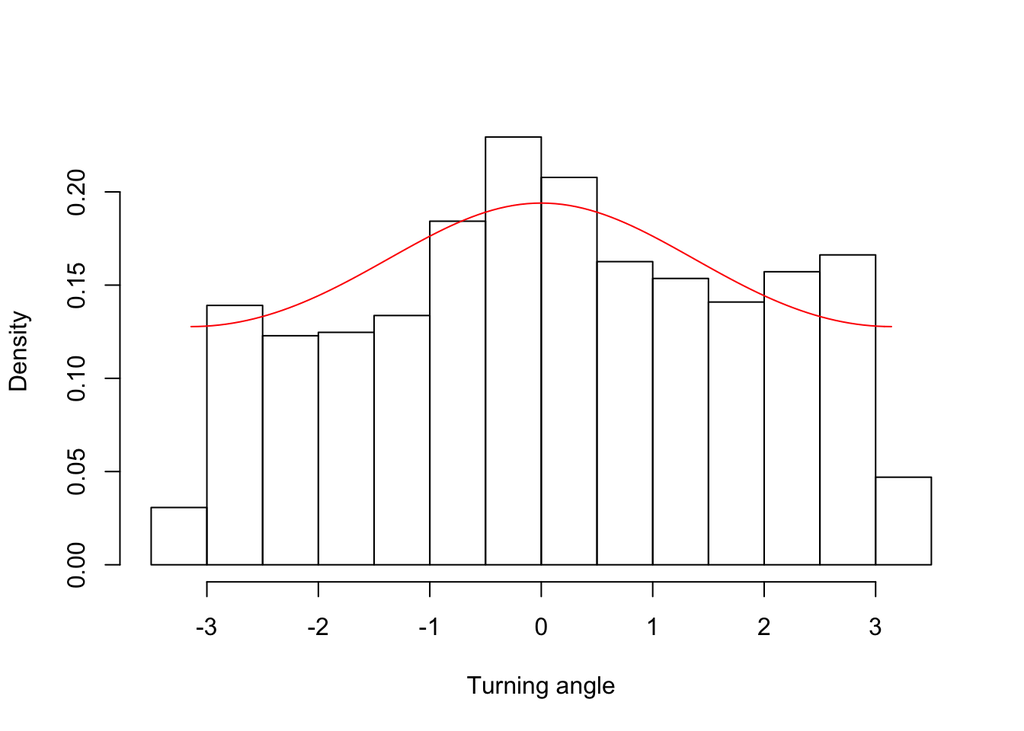

```r
hist(rel.angle3, prob = TRUE, main = "", xlab = "Turning angle")
# use distribution von Mi
plot(function(x) dvonmises(x, circular(0), kappa=fkappa), add = TRUE, from = -pi, to = pi, col = "red")
```

#### Next, we make sure we have not included data with steps > 3 hours.

```r
# subset bursted list for bursts that have turn angle data

# index for turn angle does not equal NA
sub.index <- which(is.na(ta.data$turn.angle3)==F)

# return first burst turn angle to NA (it cannot be estimated)
ta.data$turn.angle3[1] <- NA
rel.angle3[1] <- NA

# subset bursted list
burstlyl29.2 <- burstlyl29[sub.index]

#check timeLags
timeLags <- numeric(length(burstlyl29.2))

# calculate timeLags by looping over
for(i in 1:length(burstlyl29.2)){
  timeLags[i] <- timeLag(burstlyl29.2[[i]], units="hours")

}

# inspect timeLags to make sure < than maximum step, which we set as 3 hours
head(timeLags)
```

```
## [1] 2.000000 2.000000 2.033333 1.966667 2.000000 2.000000
```

```r
max(timeLags)
```

```
## [1] 2.983333
```

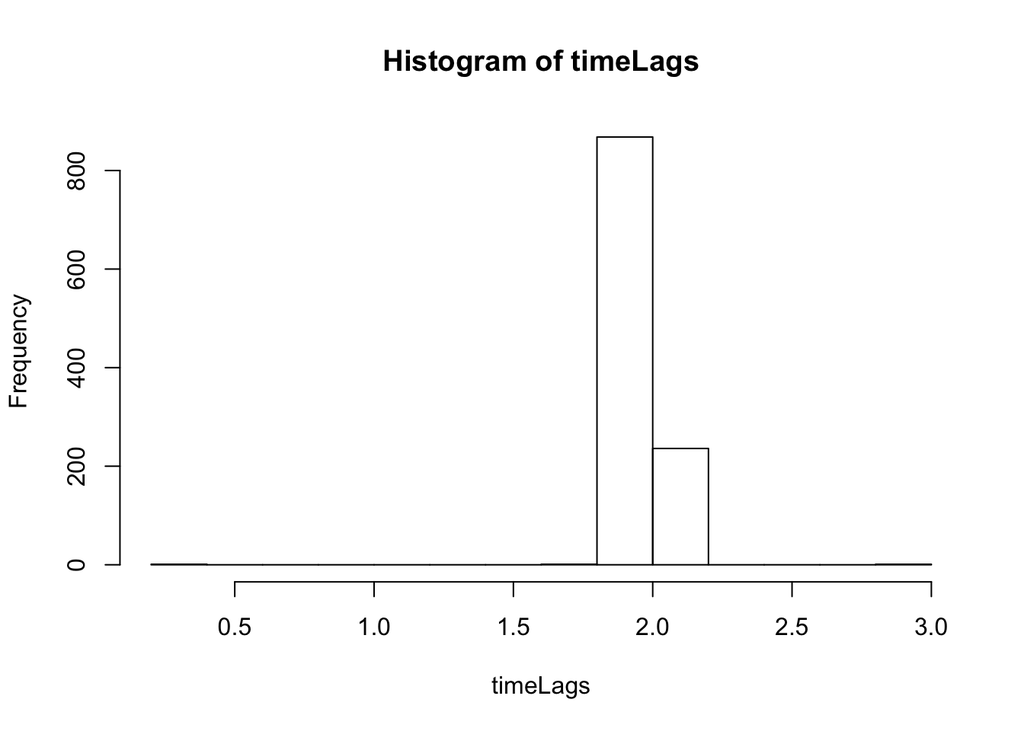

```r
# look at time lag between successive locations
hist(timeLags)
```

```r
summary(timeLags)
```

```
##    Min. 1st Qu.  Median    Mean 3rd Qu.    Max.
##   0.250   2.000   2.000   1.999   2.000   2.983
```

##### So most of the data are 2 hours, but there are some missed locations (GPS error) that we need to think about. Outliers can have a BIG effect on the spread of availability around a point. #So, lets set step duration to thin movement data into <3 hour intervals

#### Objective 2.0 Create match case control data points

##### Now with these step length and turning angle distributions we are going to sample availability

```r
utm_crs <-CRS("+proj=utm +zone=11 +datum=NAD83 +units=m +no_defs +ellps=GRS80 +towgs84=0,0,0")

#Control steps: sample with one of the following distance distributions: exponential,
#gamma, lognormal, halfnormal, potentially drawing turning angles from a von Mises
#distribution. We will use an lognormal distribution here because it seems to fit the
#data well (the gamma and exponential seem to fit pretty close as well). We will use a radially symmetric proposal
#distribution because it is easier to interpret parameter estimates for
#cos(rel.angle), and because in an earlier analysis on these data it showed less
#residual autocorrelation (note that this was not checked for the elk dataset).

# create empty data frame to hold moveBursts in
newdata <- as.data.frame(matrix(nrow=(length(burstlyl29.2)),ncol=9))
names(newdata) <- names(burstlyl29.2[[1]]@data)
newdata$Date <- as.Date(newdata$Date)
newdata$rtime <- as.POSIXct(newdata$rtime,  format="%Y-%m-%d %H:%M:%S", tz="America/Denver")
newdata$individual.local.identifier <- as.character(newdata$individual.local.identifier)
newdata$sensor <- as.character(newdata$sensor)
newdata$Time <- as.character(newdata$Time)

#make new dataset with just 1st coordinate of each moveBurst
for(i in 1:length(burstlyl29.2)){

  newdata[i,] <-    as.data.frame(burstlyl29.2[[i]]@data[1,])

}

# Mannual add data from colums 8 and 9
newdata[,8] <- rep("X29", nrow(newdata))
newdata[,9] <- rep("unknown", nrow(newdata))

# add in turn angles and distances
newdata$dist <- dist
newdata$rel.angle3 <- rel.angle3
newdata$abs.angle3 <- abs.angle3
```

##### Split data and prepare sampling loop to create match case sample of K - 5 for each USED telemetry point- here we modified the original code from Bjorn. This is a custom function to create ssf with MoveBursts; data input is a list of locations; note that the variables “ID2”, “SORTID”, “UTMX”, “UTMY”, “abs.angle3 are used in this function that is specific to the dataset. You will have to customize the function a bit if these variables do not exist or change names to these varaibles in the function below

```r
# split data into list based on ID2 variable
data_split <- split(newdata, newdata$ID2)
```

```r
## note something weird was happening in Rmd with the prepare_ssf_burst function
#source("prepare_ssf_burst_eacker.R")
prepare_ssf_burst <- function(data=NULL, K=NULL, theta=NULL, kappa=NULL, distr = "lognormal"){

  # create empty lists to hold results of for loop
  ssf_data1 <- vector("list",(length(data)))
  temp_data <- vector("list",(length(data)))
  temp_data2 <- vector("list",(length(data)))
  temp_data3 <- vector("list",(length(data)))
  data2 <- data

  for(i in 2:length(data2)){

    #sample turning angle
    r <- switch(distr,
                exponential = rexp(K, theta),
                gamma = rgamma(K, theta[1], theta[2]),
                lognormal = rlnorm(K, theta[1], theta[2]),
                halfnormal = abs(rnorm(K, 0, sqrt(pi/2)/theta)))
    start_angles <- rep(data2[[i]]$abs.angle3,K)
    theta2 <- rvonmises(K, circular(0), kappa) + start_angles
    dx <- r * cos(theta2)
    dy <- r * sin(theta2)
    temp_data[[i]] <- data.frame(cbind(dx, dy) )
    temp_data2[[i]] <- rbind(cbind(data2[[i]]$UTMX, data2[[i]]$UTMY),
                             cbind(temp_data[[i]][,1] + data2[[i]]$UTMX, temp_data[[i]][,2] + data2[[i]]$UTMY))
    temp_data3[[i]] <- cbind(temp_data[[i]][,1] + data2[[i]]$UTMX, temp_data[[i]][,2] + data2[[i]]$UTMY)
    abs.angle <- atan2(temp_data3[[i]][,2] - data2[[i]]$UTMY, temp_data3[[i]][,1] - data2[[i]]$UTMX)
    abs.angle2 <- (abs.angle - data2[[i-1]]$abs.angle3) # make i-1
    rel.angle3 <- ifelse(abs(abs.angle2) > pi, sign(abs.angle2) * (abs(abs.angle2) - 2 * pi), abs.angle2)
    ssf_data1[[i]]<- data.frame(rep(data2[[i]]$individual.local.identifier,K+1),temp_data2[[i]][,1],temp_data2[[i]][,2],
                                rep(data2[[i]]$rtime,K+1),
                                rep(paste(data2[[i]]$individual.local.identifier,"_",data2[[i]]$ID2,"_",
                                          data2[[i]]$SORTID,sep=""),K+1),
                                c(1, rep(0, K)),
                                c(data2[[i]]$dist, r),
                                c(data2[[i]]$rel.angle3,rel.angle3))

  }

  ssf_data2 <- rbindlist(ssf_data1)
  class(ssf_data2) <- "data.frame"
  names(ssf_data2) <- c("id","Easting","Northing","rtime","stratum","used","dist","rel.angle")
  ssf_data<-SpatialPointsDataFrame(ssf_data2[,c("Easting","Northing")], ssf_data2[,c(1:ncol(ssf_data2))])
  proj4string(ssf_data) <- utm_crs
  return(ssf_data)
}
```

```r
set.seed(5)
# note that data much be in a list of MoveBursts
ssf_out <- prepare_ssf_burst(data=data_split, K=5, theta=flogn$estimate, kappa=fkappa, dist = "lognormal")
head(ssf_out)
## note this can take several seconds
```

```r
load("ssf_out.R")
head(ssf_out)
```

```
##    id  Easting Northing               rtime   stratum used       dist
## 1 X29 603106.0  5734550 2003-05-02 02:00:00 X29_903_2    1   27.01851
## 2 X29 603070.7  5734511 2003-05-02 02:00:00 X29_903_2    0   52.91317
## 3 X29 601835.9  5734550 2003-05-02 02:00:00 X29_903_2    0 1270.07798
## 4 X29 603130.9  5734535 2003-05-02 02:00:00 X29_903_2    0   29.26653
## 5 X29 603218.6  5734708 2003-05-02 02:00:00 X29_903_2    0  194.37571
## 6 X29 602021.0  5732839 2003-05-02 02:00:00 X29_903_2    0 2026.34804
##    rel.angle
## 1 -0.7369204
## 2 -1.4519084
## 3 -2.2914219
## 4  0.2974169
## 5  1.8031632
## 6 -1.2853835
```

##### And next, we will graphically check control and case points graphically for one stratum, the 903-905th locations

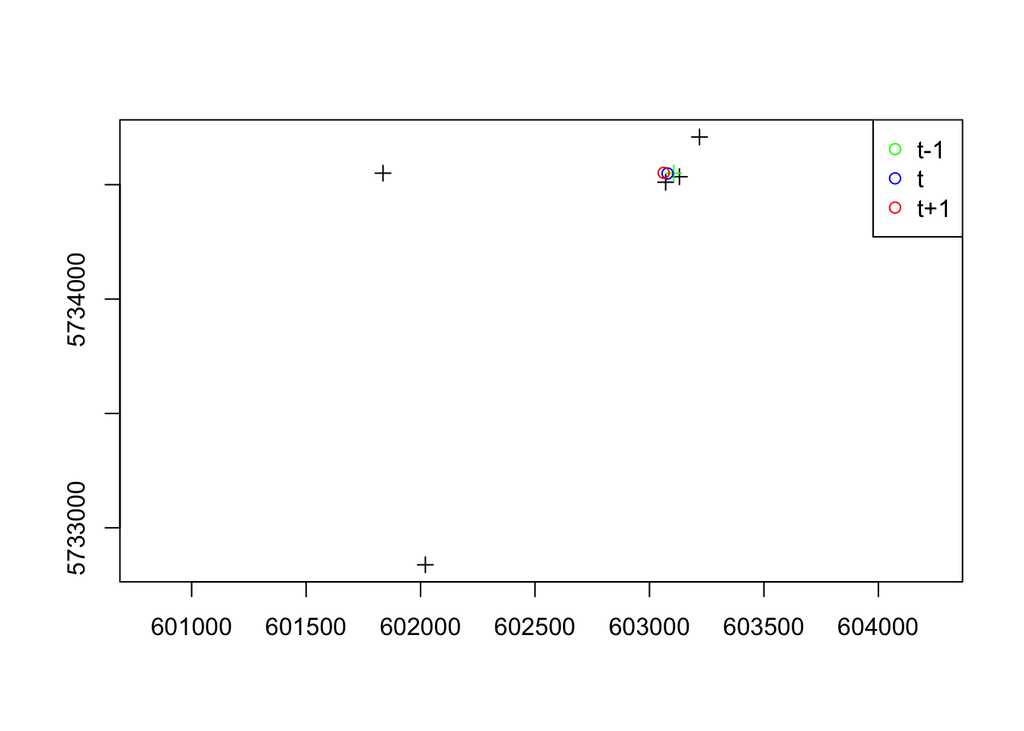

```r
# check that available points make sense
dat0 <- subset(ssf_out, stratum == "X29_903_2" & used == 0)
dat1 <- subset(ssf_out, stratum == "X29_903_2" & used == 1)
plot(dat0, axes=TRUE)
plot(dat1, add=T, col="green")
points(subset(ssf_out, stratum == "X29_904_3" & used == 1), col ="blue")
points(subset(ssf_out, stratum == "X29_905_4" & used == 1), col ="red")
dat2 <- as.data.frame(subset(ssf_out, stratum %in% c("X29_903_2", "X29_904_3") & used == 1))
lines(dat2$x, dat2$y, col ="green")             ## note lines do not plot - need to FIX
legend("topright", col = c("green", "blue", "red"), pch = 1, legend = c("t-1", "t", "t+1"))
```

#### Evaluating the effects of thinning on the set of availability

##### Create ssf for Move object using all of the data for later comparison between the thinned (above) and unthinned data based jsut on the original move object, yl29, without thinning.

```r
angle_dist <- prepare_angle_dist(yl29.mv)
# Inspect the data
summary(angle_dist)
```

```
##       dist           rel.angle
##  Min.   :    1.0   Min.   :-3.14129
##  1st Qu.:   94.4   1st Qu.:-1.20322
##  Median :  251.9   Median : 0.04382
##  Mean   :  584.8   Mean   : 0.07296
##  3rd Qu.:  589.7   3rd Qu.: 1.41643
##  Max.   :21159.5   Max.   : 3.13690
```

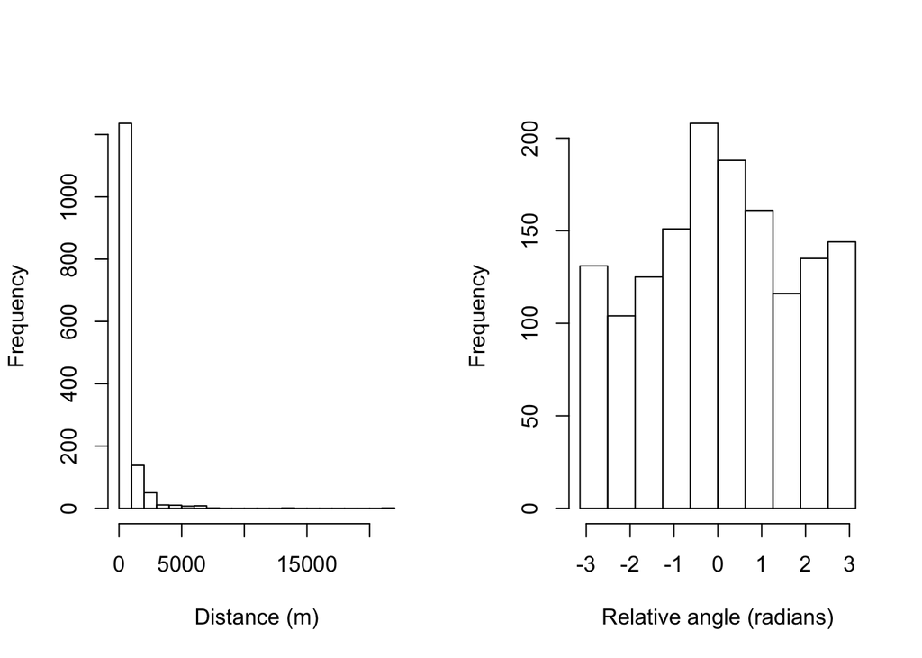

```r
dist <- angle_dist[,1]
rel.angle3 <- angle_dist[,2]

# examine empirical distances and turning angles
par(mfrow = c(1, 2))
hist(dist, breaks = 20, main = "", xlab = "Distance (m)")
hist(rel.angle3, breaks = seq(-pi, pi,len=11), main="", xlab="Relative angle (radians)")
```

```r
# Fit distributions to distances
fexp <- fitdistr(dist, "exponential")
fgam <- fitdistr(dist, "gamma")
flogn <- fitdistr(dist, "lognormal")

AICout <- AIC(flogn, fgam, fexp)
AICout <- cbind(AICout, c(0, diff(AICout$AIC)))
names(AICout) <- c("df", "AIC", "deltaAIC")
AICout
```

```
##       df      AIC deltaAIC
## flogn  2 21179.13   0.0000
## fgam   2 21350.92 171.7885
## fexp   1 21570.47 219.5438
```

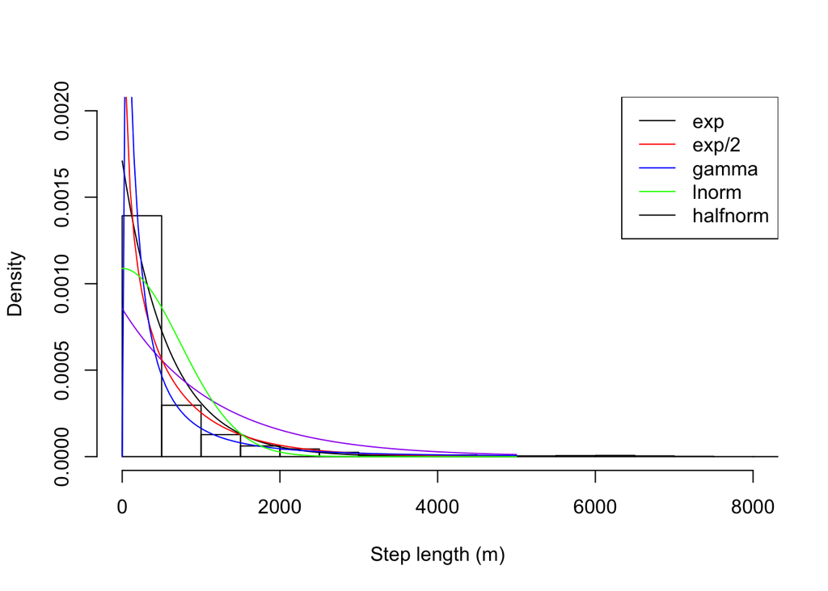

```r
## So logn STILL seems to be the best fitting function

par(mfrow = c(1,1))
hist(dist, breaks = 50, prob = TRUE, xlim = c(0, 8000), ylim = c(0, 2e-3),xlab = "Step length (m)", main = "")
plot(function(x) dexp(x, rate = fexp$estimate), add = TRUE, from = 0, to = 5000)
plot(function(x) dexp(x, rate = fexp$estimate/2), add = TRUE, from = 0, to = 5000, col="purple")
plot(function(x) dgamma(x, shape = fgam$estimate["shape"], rate = fgam$estimate["rate"]), add = TRUE,
     from = 0, to = 5000, col = "red")
plot(function(x) dlnorm(x, meanlog = flogn$estimate["meanlog"],
                        sdlog = flogn$estimate["sdlog"]), add = TRUE,
     from = 0, to = 5000, col = "blue")
plot(function(x) dhalfnorm(x, theta = 1/mean(dist)), add = TRUE,
     from = 0, to = 5000, col = "green")
legend("topright", lty = 1, col = c("black", "red", "blue", "green"),
       legend = c("exp","exp/2" ,"gamma", "lnorm", "halfnorm"))
```

```r
# Fit distributions to angles
fkappa <- est.kappa(rel.angle3)
fkappa
```

```
## [1] 0.2274643
```

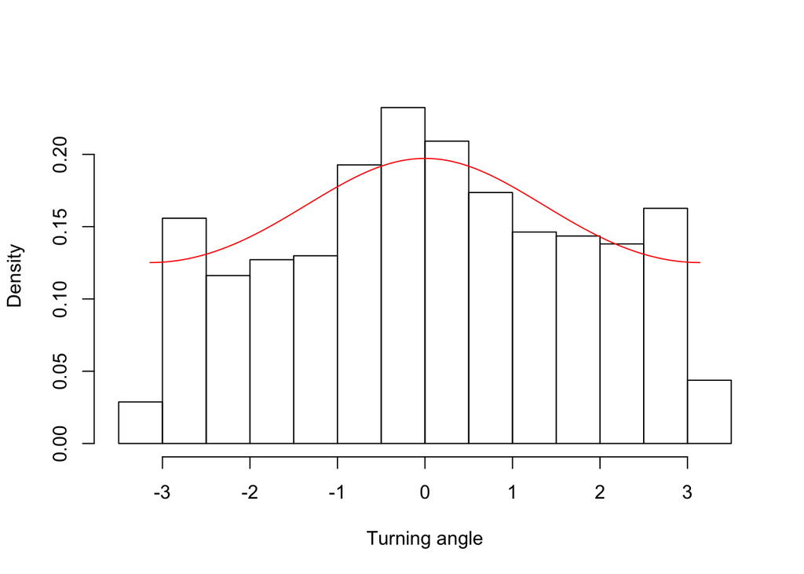

```r
hist(rel.angle3, prob = TRUE, main = "", xlab = "Turning angle")
# use distribution von Mi
plot(function(x) dvonmises(x, circular(0), kappa=fkappa), add = TRUE, from = -pi, to = pi, col = "red")
```

##### Here, we run prepare_ssf_steps on elk yl29.mv using these specific movement parameters, which were not really that different, using the un-thinned data

```r
# set projection for estimation
utm_crs <- "+proj=utm +zone=11 +datum=NAD83 +units=m +no_defs +ellps=GRS80 +towgs84=0,0,0"

# set the number of control locations
my_K <- 5

# set random number generating seed
set.seed(5)

# use prepare_ssf_steps to create the step selection function data
ssf_data3 <- prepare_ssf_steps(yl29.mv,
                               method = "lognormal", K = my_K,
                               theta = flogn$estimate, kappa = fkappa,
                               crs = utm_crs)

#set projection to UTMs
ssf_data4 <- spTransform(ssf_data3 , CRS("+proj=utm +zone=11 +datum=NAD83 +units=m +no_defs +ellps=GRS80 +towgs84=0,0,0"))
```

#### Make plot of thinned and unthinned data for elk yl29. This is comparing what thinning to just be 2 hour locations versus not thinning does to our sample of availability.

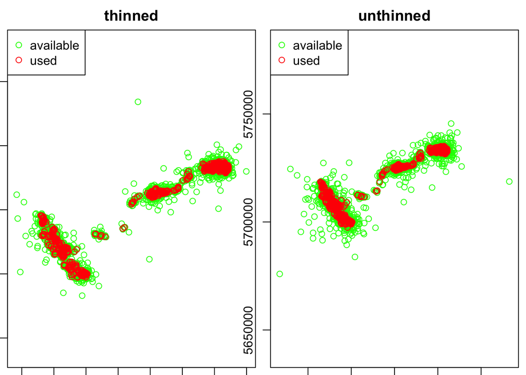

```r
#tiff("ssf_yl29_bursted_all3.tiff", res=100, compression = "lzw", height=5, width=10, units="in")
# Note this # text here and at the bottom just saves it to the working directory as a tiff.
par(mfrow=c(1,2), mar = c(0.5, 0.5, 2, 0.5))

used1 <- ssf_out[ssf_out$used==1,]
used0 <- ssf_out[ssf_out$used==0,]
plot(used0, col="green",pch = 1,main="thinned",axes=T)
plot(used1, col="red", add=T, ,pch = 1)
legend("topleft", legend=c("available", "used"), col = c("green","red"),pch = 1)

used1 <- ssf_data4[ssf_data4$used==1,]
used0 <- ssf_data4[ssf_data4$used==0,]
plot(used0, col="green",pch = 1, main="unthinned",axes=T)
plot(used1, col="red", add=T,pch = 1)
legend("topleft", legend=c("available", "used"), col = c("green","red"),pch = 1)
```

```r
#dev.off()
```

#### Objective 3.0 Build covariate dataset with Raster Layers

```r
#### match data for raster layer covariate

#set working directory to load covariate rasters
rasterDirectory = "/Users/mark.hebblewhite/Dropbox/WILD 562/Spring2017/wild562_gisdata/"
setwd(rasterDirectory)
getwd()
```

```
## [1] "/Users/mark.hebblewhite/Dropbox/WILD 562/Spring2017/wild562_gisdata"
```

```r
list.files()
```

```
##  [1] "deer_w2.tif"                  "DistFromHighHumanAccess2.tif"
##  [3] "DistFromHumanAccess2.tif"     "elc_habitat.dbf"
##  [5] "elc_habitat.prj"              "elc_habitat.sbn"
##  [7] "elc_habitat.sbx"              "elc_habitat.shp"
##  [9] "elc_habitat.shp.xml"          "elc_habitat.shx"
## [11] "Elevation2.tif"               "elk_w2.tif"
## [13] "goat_w.tif"                   "goat_w2.tif"
## [15] "landcover.tif"                "landcover16.tif"
## [17] "moose_w2.tif"                 "sheep_w2.tif"
## [19] "wolf_w2.tif"
```

```r
#### Note I have cleaned up all these GIS files and they are in the same extent and projection using resample()
#### See lab 1 and 4 for details.

elevation<-raster("Elevation2.tif") #resampled
disthumanaccess2<-raster("DistFromHumanAccess2.tif") #resampled
disthhu<-raster("DistFromHighHumanAccess2.tif")
landcover<-raster("landcover.tif") # DAN it would be great if you could help me figure out an easier way to associate the 'legend' with the ID's in this file - the file comes in with an empty list in landcover@data@attributes, and the code from lab 4 didnt quite work tonight so I punted.

all_rasters <- stack(elevation, disthumanaccess2, disthhu, landcover)

#### Just to make sure ssf_data is in the right projection just in case
#ssf_data2 <- spTransform(ssf_data, CRS("+proj=utm +zone=11 +ellps=GRS80 +towgs84=0,0,0,0,0,0,0 +units=m +no_defs"))

all_points<-SpatialPoints(coordinates(ssf_data4), proj4string=CRS("+proj=utm +zone=11 +ellps=GRS80 +towgs84=0,0,0,0,0,0,0 +units=m +no_defs"))

# extract covariates
cov.ext<-extract(all_rasters, all_points)
head(cov.ext)
```

```
##      Elevation2 DistFromHumanAccess2 DistFromHighHumanAccess2 landcover
## [1,]   1703.973             20.31597                 99.88934         7
## [2,]   1701.660             50.31597                 69.88934         7
## [3,]   1753.267            159.68403                279.88934         8
## [4,]   1721.827             69.68403                189.88934         8
## [5,]   1729.827             42.58656                  0.00000        10
## [6,]   1688.007            102.58656                393.54140         8
```

```r
str(cov.ext)
```

```
##  num [1:8784, 1:4] 1704 1702 1753 1722 1730 ...
##  - attr(*, "dimnames")=List of 2
##   ..$ : NULL
##   ..$ : chr [1:4] "Elevation2" "DistFromHumanAccess2" "DistFromHighHumanAccess2" "landcover"
```

```r
# add extracted covariates to ssf_data
ssf_data4@data$elevation <- cov.ext[,1]
ssf_data4@data$distha <- cov.ext[,2]
ssf_data4@data$disthha <- cov.ext[,3]
ssf_data4@data$landcover <- cov.ext[,4]
head(ssf_data4)
```

```
##                  date used  id stratum burst       dist  rel.angle
## 3 2003-05-02 02:00:00    1 X29 X29_0_2     0   27.01851 -0.7369204
## 4 2003-05-02 04:00:00    1 X29 X29_0_3     0   17.26268  0.2116870
## 5 2003-05-02 06:02:00    1 X29 X29_0_4     0  301.57255  2.0734513
## 6 2003-05-02 08:00:00    1 X29 X29_0_5     0  142.39382  2.9782207
## 7 2003-05-02 10:00:00    1 X29 X29_0_6     0  618.85701  1.9705841
## 8 2003-05-02 12:00:00    1 X29 X29_0_7     0 1381.92945 -0.9666432
##   elevation    distha   disthha landcover
## 3  1703.973  20.31597  99.88934         7
## 4  1701.660  50.31597  69.88934         7
## 5  1753.267 159.68403 279.88934         8
## 6  1721.827  69.68403 189.88934         8
## 7  1729.827  42.58656   0.00000        10
## 8  1688.007 102.58656 393.54140         8
```

```r
### Add landcover categories to ssf_data, next 3 steps are just to read in the legend codes again if you need
#setwd("/Users/mark.hebblewhite/Dropbox/WILD 562/Spring2017/Lab8/")
#landcover.legend <- read.csv("landcover_legend.csv", header = TRUE, sep = ",")
#landcover.legend

ssf_data4@data$landcover.cat = ifelse(ssf_data4@data$landcover == 0, "NA",
       ifelse(ssf_data4@data$landcover == 1, "Open Conifer",
          ifelse(ssf_data4@data$landcover == 2, "Moderate Conifer",
             ifelse(ssf_data4@data$landcover == 3, "Closed Conifer",
                ifelse(ssf_data4@data$landcover == 4, "Deciduous",
                   ifelse(ssf_data4@data$landcover == 5, "Mixed",
                      ifelse(ssf_data4@data$landcover == 6, "Regen",
                        ifelse(ssf_data4@data$landcover == 7, "Herbaceous",
                           ifelse(ssf_data4@data$landcover == 8, "Shrub",
                              ifelse(ssf_data4@data$landcover == 9, "Water",
                                 ifelse(ssf_data4@data$landcover == 10, "Rock-Ice",
                                    ifelse(ssf_data4@data$landcover == 11, "Cloud",
                                         ifelse(ssf_data4@data$landcover == 12, "Burn-Forest",
                                               ifelse(ssf_data4@data$landcover == 13, "Burn-Grassland",
                                                    ifelse(ssf_data4@data$landcover == 14, "Burn-Shrub",
                                                           ifelse(ssf_data4@data$landcover == 15, "Alpine Herb", "Alpine Shrub"))))))))))))))))
table(ssf_data4$landcover.cat, ssf_data4$used)
```

```
##
##                       0    1
##   Alpine Herb       142   28
##   Alpine Shrub      148   38
##   Burn-Forest       168   35
##   Burn-Grassland     39    8
##   Burn-Shrub         12    2
##   Closed Conifer   1707  283
##   Deciduous          11    3
##   Herbaceous       1150  252
##   Mixed             229   54
##   Moderate Conifer 1662  276
##   NA                  7    0
##   Open Conifer      555  110
##   Rock-Ice          412   46
##   Shrub            1048  327
##   Water              18    2
```

```r
head(ssf_data4)
```

```
##                  date used  id stratum burst       dist  rel.angle
## 3 2003-05-02 02:00:00    1 X29 X29_0_2     0   27.01851 -0.7369204
## 4 2003-05-02 04:00:00    1 X29 X29_0_3     0   17.26268  0.2116870
## 5 2003-05-02 06:02:00    1 X29 X29_0_4     0  301.57255  2.0734513
## 6 2003-05-02 08:00:00    1 X29 X29_0_5     0  142.39382  2.9782207
## 7 2003-05-02 10:00:00    1 X29 X29_0_6     0  618.85701  1.9705841
## 8 2003-05-02 12:00:00    1 X29 X29_0_7     0 1381.92945 -0.9666432
##   elevation    distha   disthha landcover landcover.cat
## 3  1703.973  20.31597  99.88934         7    Herbaceous
## 4  1701.660  50.31597  69.88934         7    Herbaceous
## 5  1753.267 159.68403 279.88934         8         Shrub
## 6  1721.827  69.68403 189.88934         8         Shrub
## 7  1729.827  42.58656   0.00000        10      Rock-Ice
## 8  1688.007 102.58656 393.54140         8         Shrub
```

```r
str(ssf_data4)
```

```
## Formal class 'SpatialPointsDataFrame' [package "sp"] with 5 slots
##   ..@ data       :'data.frame':  8784 obs. of  12 variables:
##   .. ..$ date         : POSIXct[1:8784], format: "2003-05-02 02:00:00" ...
##   .. ..$ used         : num [1:8784] 1 1 1 1 1 1 1 1 1 1 ...
##   .. ..$ id           : Factor w/ 1 level "X29": 1 1 1 1 1 1 1 1 1 1 ...
##   .. ..$ stratum      : chr [1:8784] "X29_0_2" "X29_0_3" "X29_0_4" "X29_0_5" ...
##   .. ..$ burst        : Factor w/ 1 level "0": 1 1 1 1 1 1 1 1 1 1 ...
##   .. ..$ dist         : num [1:8784] 27 17.3 301.6 142.4 618.9 ...
##   .. ..$ rel.angle    : num [1:8784] -0.737 0.212 2.073 2.978 1.971 ...
##   .. ..$ elevation    : num [1:8784] 1704 1702 1753 1722 1730 ...
##   .. ..$ distha       : num [1:8784] 20.3 50.3 159.7 69.7 42.6 ...
##   .. ..$ disthha      : num [1:8784] 99.9 69.9 279.9 189.9 0 ...
##   .. ..$ landcover    : num [1:8784] 7 7 8 8 10 8 8 8 8 8 ...
##   .. ..$ landcover.cat: chr [1:8784] "Herbaceous" "Herbaceous" "Shrub" "Shrub" ...
##   ..@ coords.nrs : num(0)
##   ..@ coords     : num [1:8784, 1:2] 603079 603062 603251 603181 602803 ...
##   .. ..- attr(*, "dimnames")=List of 2
##   .. .. ..$ : chr [1:8784] "3" "4" "5" "6" ...
##   .. .. ..$ : chr [1:2] "x" "y"
##   ..@ bbox       : num [1:2, 1:2] 526935 5675935 633027 5745562
##   .. ..- attr(*, "dimnames")=List of 2
##   .. .. ..$ : chr [1:2] "x" "y"
##   .. .. ..$ : chr [1:2] "min" "max"
##   ..@ proj4string:Formal class 'CRS' [package "sp"] with 1 slot
##   .. .. ..@ projargs: chr "+proj=utm +zone=11 +datum=NAD83 +units=m +no_defs +ellps=GRS80 +towgs84=0,0,0"
```

```r
summary(ssf_data4)
```

```
## Object of class SpatialPointsDataFrame
## Coordinates:
##         min     max
## x  526935.1  633027
## y 5675934.5 5745562
## Is projected: TRUE
## proj4string :
## [+proj=utm +zone=11 +datum=NAD83 +units=m +no_defs +ellps=GRS80
## +towgs84=0,0,0]
## Number of points: 8784
## Data attributes:
##       date                          used          id
##  Min.   :2003-05-02 02:00:00   Min.   :0.0000   X29:8784
##  1st Qu.:2003-06-03 03:30:00   1st Qu.:0.0000
##  Median :2003-07-18 11:00:30   Median :0.0000
##  Mean   :2003-07-24 10:29:59   Mean   :0.1667
##  3rd Qu.:2003-09-09 19:00:45   3rd Qu.:0.0000
##  Max.   :2003-10-30 20:00:00   Max.   :1.0000
##
##    stratum          burst         dist            rel.angle
##  Length:8784        0:8784   Min.   :    1.00   Min.   :-3.141290
##  Class :character            1st Qu.:   85.74   1st Qu.:-1.326164
##  Mode  :character            Median :  229.01   Median :-0.004319
##                              Mean   :  671.91   Mean   : 0.008864
##                              3rd Qu.:  617.62   3rd Qu.: 1.316997
##                              Max.   :47274.97   Max.   : 3.141384
##
##    elevation        distha          disthha           landcover
##  Min.   :1265   Min.   :   0.0   Min.   :    0.00   Min.   : 0.000
##  1st Qu.:1660   1st Qu.: 105.1   1st Qu.:   78.42   1st Qu.: 2.000
##  Median :1761   Median : 298.9   Median :  502.23   Median : 3.000
##  Mean   :1837   Mean   : 546.9   Mean   : 1682.62   Mean   : 5.281
##  3rd Qu.:1970   3rd Qu.: 800.0   3rd Qu.: 1467.13   3rd Qu.: 8.000
##  Max.   :3259   Max.   :4375.6   Max.   :14856.74   Max.   :16.000
##                                                     NA's   :12
##  landcover.cat
##  Length:8784
##  Class :character
##  Mode  :character
##
##
##
##
```

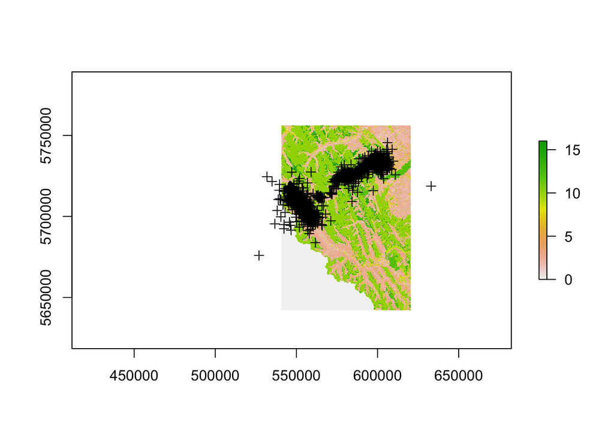

```r
par(mfrow=c(1,1))
plot(landcover)
plot(ssf_data4, add = TRUE)
```

#### Note that sometimes there are some NA landcover variables which fell outside the domain of availability for landcover, e.g., in BC. Therefore, we next have to delete the NA’s in ssf_data5. Lets just pull out the data frame from ssf_data4

```r
ssf_data5<-ssf_data4@data
head(ssf_data5)
```

```
##                  date used  id stratum burst       dist  rel.angle
## 3 2003-05-02 02:00:00    1 X29 X29_0_2     0   27.01851 -0.7369204
## 4 2003-05-02 04:00:00    1 X29 X29_0_3     0   17.26268  0.2116870
## 5 2003-05-02 06:02:00    1 X29 X29_0_4     0  301.57255  2.0734513
## 6 2003-05-02 08:00:00    1 X29 X29_0_5     0  142.39382  2.9782207
## 7 2003-05-02 10:00:00    1 X29 X29_0_6     0  618.85701  1.9705841
## 8 2003-05-02 12:00:00    1 X29 X29_0_7     0 1381.92945 -0.9666432
##   elevation    distha   disthha landcover landcover.cat
## 3  1703.973  20.31597  99.88934         7    Herbaceous
## 4  1701.660  50.31597  69.88934         7    Herbaceous
## 5  1753.267 159.68403 279.88934         8         Shrub
## 6  1721.827  69.68403 189.88934         8         Shrub
## 7  1729.827  42.58656   0.00000        10      Rock-Ice
## 8  1688.007 102.58656 393.54140         8         Shrub
```

```r
str(ssf_data5)
```

```
## 'data.frame':    8784 obs. of  12 variables:
##  $ date         : POSIXct, format: "2003-05-02 02:00:00" "2003-05-02 04:00:00" ...
##  $ used         : num  1 1 1 1 1 1 1 1 1 1 ...
##  $ id           : Factor w/ 1 level "X29": 1 1 1 1 1 1 1 1 1 1 ...
##  $ stratum      : chr  "X29_0_2" "X29_0_3" "X29_0_4" "X29_0_5" ...
##  $ burst        : Factor w/ 1 level "0": 1 1 1 1 1 1 1 1 1 1 ...
##  $ dist         : num  27 17.3 301.6 142.4 618.9 ...
##  $ rel.angle    : num  -0.737 0.212 2.073 2.978 1.971 ...
##  $ elevation    : num  1704 1702 1753 1722 1730 ...
##  $ distha       : num  20.3 50.3 159.7 69.7 42.6 ...
##  $ disthha      : num  99.9 69.9 279.9 189.9 0 ...
##  $ landcover    : num  7 7 8 8 10 8 8 8 8 8 ...
##  $ landcover.cat: chr  "Herbaceous" "Herbaceous" "Shrub" "Shrub" ...
```

```r
ssf_data5 <- ssf_data5[complete.cases(ssf_data5[1:12]),]
summary(ssf_data5)
```

```
##       date                          used          id
##  Min.   :2003-05-02 02:00:00   Min.   :0.0000   X29:8772
##  1st Qu.:2003-06-03 02:00:00   1st Qu.:0.0000
##  Median :2003-07-18 08:01:00   Median :0.0000
##  Mean   :2003-07-24 10:34:33   Mean   :0.1669
##  3rd Qu.:2003-09-09 22:00:00   3rd Qu.:0.0000
##  Max.   :2003-10-30 20:00:00   Max.   :1.0000
##    stratum          burst         dist            rel.angle
##  Length:8772        0:8772   Min.   :    1.00   Min.   :-3.141290
##  Class :character            1st Qu.:   85.44   1st Qu.:-1.326731
##  Mode  :character            Median :  228.34   Median :-0.005282
##                              Mean   :  645.57   Mean   : 0.008333
##                              3rd Qu.:  615.61   3rd Qu.: 1.317557
##                              Max.   :22344.98   Max.   : 3.141384
##    elevation        distha          disthha           landcover
##  Min.   :1520   Min.   :   0.0   Min.   :    0.00   Min.   : 0.000
##  1st Qu.:1660   1st Qu.: 105.1   1st Qu.:   77.94   1st Qu.: 2.000
##  Median :1760   Median : 298.8   Median :  502.11   Median : 3.000
##  Mean   :1837   Mean   : 546.5   Mean   : 1681.51   Mean   : 5.281
##  3rd Qu.:1970   3rd Qu.: 799.8   3rd Qu.: 1467.03   3rd Qu.: 8.000
##  Max.   :3259   Max.   :4375.6   Max.   :14856.74   Max.   :16.000
##  landcover.cat
##  Length:8772
##  Class :character
##  Mode  :character
##
##
##
```

```r
nrow(ssf_data5)
```

```
## [1] 8772
```

#### Objective 4.0 FIT step selection function Clogit model

```r
## first make sure we understand the stratum field
head(ssf_data5)
```

```
##                  date used  id stratum burst       dist  rel.angle
## 3 2003-05-02 02:00:00    1 X29 X29_0_2     0   27.01851 -0.7369204
## 4 2003-05-02 04:00:00    1 X29 X29_0_3     0   17.26268  0.2116870
## 5 2003-05-02 06:02:00    1 X29 X29_0_4     0  301.57255  2.0734513
## 6 2003-05-02 08:00:00    1 X29 X29_0_5     0  142.39382  2.9782207
## 7 2003-05-02 10:00:00    1 X29 X29_0_6     0  618.85701  1.9705841
## 8 2003-05-02 12:00:00    1 X29 X29_0_7     0 1381.92945 -0.9666432
##   elevation    distha   disthha landcover landcover.cat
## 3  1703.973  20.31597  99.88934         7    Herbaceous
## 4  1701.660  50.31597  69.88934         7    Herbaceous
## 5  1753.267 159.68403 279.88934         8         Shrub
## 6  1721.827  69.68403 189.88934         8         Shrub
## 7  1729.827  42.58656   0.00000        10      Rock-Ice
## 8  1688.007 102.58656 393.54140         8         Shrub
```

```r
head(sort(ssf_data5$stratum))
```

```
## [1] "X29_0_10" "X29_0_10" "X29_0_10" "X29_0_10" "X29_0_10" "X29_0_10"
```

```r
head(table(ssf_data5$stratum, ssf_data5$used))
```

```
##
##              0 1
##   X29_0_10   5 1
##   X29_0_100  5 1
##   X29_0_1000 5 1
##   X29_0_1001 5 1
##   X29_0_1002 5 1
##   X29_0_1003 5 1
```

```r
### So, there are 5 matched case availabile locations for each 1 used location. It is this stratum that distinguishes clogit from logistic regression.

## start with univariate models
m.elev <- clogit(used ~ elevation + strata(stratum), data = ssf_data5)
summary(m.elev)
```

```
## Call:
## coxph(formula = Surv(rep(1, 8772L), used) ~ elevation + strata(stratum),
##     data = ssf_data5, method = "exact")
##
##   n= 8772, number of events= 1464
##
##                 coef  exp(coef)   se(coef)      z Pr(>|z|)
## elevation -0.0015172  0.9984839  0.0002968 -5.111  3.2e-07 ***
## ---
## Signif. codes:  0 '***' 0.001 '**' 0.01 '*' 0.05 '.' 0.1 ' ' 1
##
##           exp(coef) exp(-coef) lower .95 upper .95
## elevation    0.9985      1.002    0.9979    0.9991
##
## Rsquare= 0.003   (max possible= 0.45 )
## Likelihood ratio test= 28.89  on 1 df,   p=7.645e-08
## Wald test            = 26.13  on 1 df,   p=3.196e-07
## Score (logrank) test = 26.05  on 1 df,   p=3.325e-07
```

```r
#### Compare to naive logistic regression model ignoring structure
elev <- glm(used ~ elevation, data = ssf_data5, family = binomial(logit))
summary(elev)
```

```
##
## Call:
## glm(formula = used ~ elevation, family = binomial(logit), data = ssf_data5)
##
## Deviance Residuals:
##     Min       1Q   Median       3Q      Max
## -0.6320  -0.6180  -0.6068  -0.5724   1.9915
##
## Coefficients:
##               Estimate Std. Error z value Pr(>|z|)
## (Intercept) -1.0279658  0.2351055  -4.372 1.23e-05 ***
## elevation   -0.0003166  0.0001278  -2.477   0.0132 *
## ---
## Signif. codes:  0 '***' 0.001 '**' 0.01 '*' 0.05 '.' 0.1 ' ' 1
##
## (Dispersion parameter for binomial family taken to be 1)
##
##     Null deviance: 7911.1  on 8771  degrees of freedom
## Residual deviance: 7904.8  on 8770  degrees of freedom
## AIC: 7908.8
##
## Number of Fisher Scoring iterations: 4
```

#### Clogit model is the effect of elevation on probability of use GIVEN/CONDITIONED on what was available to the animal at each discrete choice set.

#### The logit model is the effect of elevation on probabiltiy of use assuming that everything was available to each elk used location. Its ALL about the assumptions of the model and the constraint to availability.

#### Compare clogit and naive logit for next variables.

```r
### Distance to human access
m.distha <- clogit(used ~ distha + strata(stratum), data = ssf_data5)
summary(m.distha)
```

```
## Call:
## coxph(formula = Surv(rep(1, 8772L), used) ~ distha + strata(stratum),
##     data = ssf_data5, method = "exact")
##
##   n= 8772, number of events= 1464
##
##              coef  exp(coef)   se(coef)      z Pr(>|z|)
## distha -4.380e-04  9.996e-01  9.923e-05 -4.414 1.02e-05 ***
## ---
## Signif. codes:  0 '***' 0.001 '**' 0.01 '*' 0.05 '.' 0.1 ' ' 1
##
##        exp(coef) exp(-coef) lower .95 upper .95
## distha    0.9996          1    0.9994    0.9998
##
## Rsquare= 0.002   (max possible= 0.45 )
## Likelihood ratio test= 20.83  on 1 df,   p=5.018e-06
## Wald test            = 19.48  on 1 df,   p=1.015e-05
## Score (logrank) test = 19.44  on 1 df,   p=1.036e-05
```

```r
distha <- glm(used ~ distha, data = ssf_data5, family = binomial(logit))
summary(distha)
```

```
##
## Call:
## glm(formula = used ~ distha, family = binomial(logit), data = ssf_data5)
##
## Deviance Residuals:
##     Min       1Q   Median       3Q      Max
## -0.6210  -0.6168  -0.6074  -0.5758   2.0089
##
## Coefficients:
##               Estimate Std. Error z value Pr(>|z|)
## (Intercept) -1.548e+00  3.829e-02 -40.428   <2e-16 ***
## distha      -1.119e-04  4.893e-05  -2.288   0.0221 *
## ---
## Signif. codes:  0 '***' 0.001 '**' 0.01 '*' 0.05 '.' 0.1 ' ' 1
##
## (Dispersion parameter for binomial family taken to be 1)
##
##     Null deviance: 7911.1  on 8771  degrees of freedom
## Residual deviance: 7905.7  on 8770  degrees of freedom
## AIC: 7909.7
##
## Number of Fisher Scoring iterations: 3
```

```r
#### Distance to high human access
m.disthha <- clogit(used ~ disthha + strata(stratum), data = ssf_data5)
summary(m.disthha)
```

```
## Call:
## coxph(formula = Surv(rep(1, 8772L), used) ~ disthha + strata(stratum),
##     data = ssf_data5, method = "exact")
##
##   n= 8772, number of events= 1464
##
##               coef  exp(coef)   se(coef)      z Pr(>|z|)
## disthha -2.609e-04  9.997e-01  6.198e-05 -4.209 2.56e-05 ***
## ---
## Signif. codes:  0 '***' 0.001 '**' 0.01 '*' 0.05 '.' 0.1 ' ' 1
##
##         exp(coef) exp(-coef) lower .95 upper .95
## disthha    0.9997          1    0.9996    0.9999
##
## Rsquare= 0.002   (max possible= 0.45 )
## Likelihood ratio test= 19.55  on 1 df,   p=9.791e-06
## Wald test            = 17.72  on 1 df,   p=2.562e-05
## Score (logrank) test = 17.54  on 1 df,   p=2.819e-05
```

```r
disthha <- glm(used ~ disthha, data = ssf_data5, family = binomial(logit))
summary(disthha)
```

```
##
## Call:
## glm(formula = used ~ disthha, family = binomial(logit), data = ssf_data5)
##
## Deviance Residuals:
##     Min       1Q   Median       3Q      Max
## -0.6080  -0.6077  -0.6062  -0.5928   1.9367
##
## Coefficients:
##               Estimate Std. Error z value Pr(>|z|)
## (Intercept) -1.594e+00  3.312e-02 -48.136   <2e-16 ***
## disthha     -8.043e-06  1.017e-05  -0.791    0.429
## ---
## Signif. codes:  0 '***' 0.001 '**' 0.01 '*' 0.05 '.' 0.1 ' ' 1
##
## (Dispersion parameter for binomial family taken to be 1)
##
##     Null deviance: 7911.1  on 8771  degrees of freedom
## Residual deviance: 7910.4  on 8770  degrees of freedom
## AIC: 7914.4
##
## Number of Fisher Scoring iterations: 3
```

```r
#### Landcover
m.landcov <- clogit(used ~ I(landcover.cat) + strata(stratum), data = ssf_data5)
summary(m.landcov)
```

```
## Call:
## coxph(formula = Surv(rep(1, 8772L), used) ~ I(landcover.cat) +
##     strata(stratum), data = ssf_data5, method = "exact")
##
##   n= 8772, number of events= 1464
##
##                                        coef  exp(coef)   se(coef)      z
## I(landcover.cat)Alpine Shrub      4.053e-01  1.500e+00  3.074e-01  1.318
## I(landcover.cat)Burn-Forest       5.212e-01  1.684e+00  3.772e-01  1.382
## I(landcover.cat)Burn-Grassland    5.338e-01  1.705e+00  5.181e-01  1.030
## I(landcover.cat)Burn-Shrub        2.316e-01  1.261e+00  8.715e-01  0.266
## I(landcover.cat)Closed Conifer   -2.273e-01  7.967e-01  2.698e-01 -0.842
## I(landcover.cat)Deciduous         9.923e-01  2.698e+00  7.494e-01  1.324
## I(landcover.cat)Herbaceous        7.947e-01  2.214e+00  2.864e-01  2.775
## I(landcover.cat)Mixed             5.039e-01  1.655e+00  3.060e-01  1.647
## I(landcover.cat)Moderate Conifer -6.307e-02  9.389e-01  2.708e-01 -0.233
## I(landcover.cat)NA               -1.437e+01  5.762e-07  1.084e+03 -0.013
## I(landcover.cat)Open Conifer      3.814e-01  1.464e+00  2.867e-01  1.330
## I(landcover.cat)Rock-Ice         -3.354e-01  7.151e-01  2.892e-01 -1.159
## I(landcover.cat)Shrub             1.079e+00  2.941e+00  2.777e-01  3.884
## I(landcover.cat)Water            -3.930e-01  6.750e-01  8.056e-01 -0.488
##                                  Pr(>|z|)
## I(landcover.cat)Alpine Shrub     0.187355
## I(landcover.cat)Burn-Forest      0.167082
## I(landcover.cat)Burn-Grassland   0.302944
## I(landcover.cat)Burn-Shrub       0.790385
## I(landcover.cat)Closed Conifer   0.399574
## I(landcover.cat)Deciduous        0.185469
## I(landcover.cat)Herbaceous       0.005519 **
## I(landcover.cat)Mixed            0.099540 .
## I(landcover.cat)Moderate Conifer 0.815865
## I(landcover.cat)NA               0.989428
## I(landcover.cat)Open Conifer     0.183458
## I(landcover.cat)Rock-Ice         0.246282
## I(landcover.cat)Shrub            0.000103 ***
## I(landcover.cat)Water            0.625628
## ---
## Signif. codes:  0 '***' 0.001 '**' 0.01 '*' 0.05 '.' 0.1 ' ' 1
##
##                                  exp(coef) exp(-coef) lower .95 upper .95
## I(landcover.cat)Alpine Shrub     1.500e+00  6.668e-01    0.8210     2.740
## I(landcover.cat)Burn-Forest      1.684e+00  5.938e-01    0.8040     3.527
## I(landcover.cat)Burn-Grassland   1.705e+00  5.864e-01    0.6177     4.708
## I(landcover.cat)Burn-Shrub       1.261e+00  7.932e-01    0.2285     6.957
## I(landcover.cat)Closed Conifer   7.967e-01  1.255e+00    0.4695     1.352
## I(landcover.cat)Deciduous        2.698e+00  3.707e-01    0.6209    11.719
## I(landcover.cat)Herbaceous       2.214e+00  4.517e-01    1.2629     3.880
## I(landcover.cat)Mixed            1.655e+00  6.041e-01    0.9087     3.015
## I(landcover.cat)Moderate Conifer 9.389e-01  1.065e+00    0.5522     1.596
## I(landcover.cat)NA               5.762e-07  1.736e+06    0.0000       Inf
## I(landcover.cat)Open Conifer     1.464e+00  6.829e-01    0.8348     2.569
## I(landcover.cat)Rock-Ice         7.151e-01  1.398e+00    0.4057     1.261
## I(landcover.cat)Shrub            2.941e+00  3.400e-01    1.7064     5.069
## I(landcover.cat)Water            6.750e-01  1.481e+00    0.1392     3.274
##
## Rsquare= 0.017   (max possible= 0.45 )
## Likelihood ratio test= 151.6  on 14 df,   p=0
## Wald test            = 140.8  on 14 df,   p=0
## Score (logrank) test = 148.7  on 14 df,   p=0
```

```r
landcov  <- glm(used ~ I(landcover.cat), data = ssf_data5, family = binomial(logit))
summary(landcov)
```

```
##
## Call:
## glm(formula = used ~ I(landcover.cat), family = binomial(logit),
##     data = ssf_data5)
##
## Deviance Residuals:
##     Min       1Q   Median       3Q      Max
## -0.7370  -0.6295  -0.5543  -0.5539   2.1460
##
## Coefficients:
##                                    Estimate Std. Error z value Pr(>|z|)
## (Intercept)                       -1.623623   0.206777  -7.852 4.09e-15
## I(landcover.cat)Alpine Shrub       0.263996   0.275371   0.959   0.3377
## I(landcover.cat)Burn-Forest        0.055007   0.277993   0.198   0.8431
## I(landcover.cat)Burn-Grassland     0.039502   0.439770   0.090   0.9284
## I(landcover.cat)Burn-Shrub        -0.168137   0.791258  -0.212   0.8317
## I(landcover.cat)Closed Conifer    -0.173423   0.216509  -0.801   0.4231
## I(landcover.cat)Deciduous          0.324340   0.683373   0.475   0.6351
## I(landcover.cat)Herbaceous         0.105534   0.218161   0.484   0.6286
## I(landcover.cat)Mixed              0.178885   0.256207   0.698   0.4850
## I(landcover.cat)Moderate Conifer  -0.171754   0.216752  -0.792   0.4281
## I(landcover.cat)NA               -11.942444 202.366506  -0.059   0.9529
## I(landcover.cat)Open Conifer       0.005135   0.231623   0.022   0.9823
## I(landcover.cat)Rock-Ice          -0.568759   0.258695  -2.199   0.0279
## I(landcover.cat)Shrub              0.458944   0.216261   2.122   0.0338
## I(landcover.cat)Water             -0.573602   0.773506  -0.742   0.4584
##
## (Intercept)                      ***
## I(landcover.cat)Alpine Shrub
## I(landcover.cat)Burn-Forest
## I(landcover.cat)Burn-Grassland
## I(landcover.cat)Burn-Shrub
## I(landcover.cat)Closed Conifer
## I(landcover.cat)Deciduous
## I(landcover.cat)Herbaceous
## I(landcover.cat)Mixed
## I(landcover.cat)Moderate Conifer
## I(landcover.cat)NA
## I(landcover.cat)Open Conifer
## I(landcover.cat)Rock-Ice         *
## I(landcover.cat)Shrub            *
## I(landcover.cat)Water
## ---
## Signif. codes:  0 '***' 0.001 '**' 0.01 '*' 0.05 '.' 0.1 ' ' 1
##
## (Dispersion parameter for binomial family taken to be 1)
##
##     Null deviance: 7911.1  on 8771  degrees of freedom
## Residual deviance: 7823.5  on 8757  degrees of freedom
## AIC: 7853.5
##
## Number of Fisher Scoring iterations: 12
```

#### Objective 4.1 Compare Predictions from full models

##### You can now get predictions from a Clogit model, but the predictions mean something very different here

##### The Cox model is a relative risk model; predictions of type “linear predictor”, “risk”, and “terms” are all relative to the sample from which they came. By default, the reference value for each of these is the mean covariate within strata. The primary underlying reason is statistical: a Cox model only predicts relative risks between pairs of subjects within the same strata, and hence the addition of a constant to any covariate, either overall or only within a particular stratum, has no effect on the fitted results. Using the reference=“strata” option causes this to be true for predictions as well.

```r
m.full  <- clogit(used ~ elevation + distha + disthha + I(landcover.cat) +strata(stratum), data = ssf_data5)
summary(m.full)
```

```
## Call:
## coxph(formula = Surv(rep(1, 8772L), used) ~ elevation + distha +
##     disthha + I(landcover.cat) + strata(stratum), data = ssf_data5,
##     method = "exact")
##
##   n= 8772, number of events= 1464
##
##                                        coef  exp(coef)   se(coef)      z
## elevation                        -9.870e-04  9.990e-01  4.341e-04 -2.274
## distha                           -1.013e-04  9.999e-01  1.462e-04 -0.693
## disthha                          -1.306e-04  9.999e-01  7.623e-05 -1.713
## I(landcover.cat)Alpine Shrub      3.443e-01  1.411e+00  3.091e-01  1.114
## I(landcover.cat)Burn-Forest       1.363e-01  1.146e+00  3.896e-01  0.350
## I(landcover.cat)Burn-Grassland    2.176e-01  1.243e+00  5.247e-01  0.415
## I(landcover.cat)Burn-Shrub       -1.237e-01  8.836e-01  8.955e-01 -0.138
## I(landcover.cat)Closed Conifer   -5.665e-01  5.675e-01  2.833e-01 -2.000
## I(landcover.cat)Deciduous         6.164e-01  1.852e+00  7.568e-01  0.814
## I(landcover.cat)Herbaceous        4.503e-01  1.569e+00  2.997e-01  1.502
## I(landcover.cat)Mixed             2.217e-01  1.248e+00  3.146e-01  0.705
## I(landcover.cat)Moderate Conifer -3.959e-01  6.731e-01  2.848e-01 -1.390
## I(landcover.cat)NA               -1.420e+01  6.813e-07  1.054e+03 -0.013
## I(landcover.cat)Open Conifer      3.891e-02  1.040e+00  3.002e-01  0.130
## I(landcover.cat)Rock-Ice         -3.262e-01  7.216e-01  2.934e-01 -1.112
## I(landcover.cat)Shrub             7.396e-01  2.095e+00  2.910e-01  2.542
## I(landcover.cat)Water            -7.194e-01  4.870e-01  8.136e-01 -0.884
##                                  Pr(>|z|)
## elevation                          0.0230 *
## distha                             0.4884
## disthha                            0.0867 .
## I(landcover.cat)Alpine Shrub       0.2654
## I(landcover.cat)Burn-Forest        0.7265
## I(landcover.cat)Burn-Grassland     0.6783
## I(landcover.cat)Burn-Shrub         0.8901
## I(landcover.cat)Closed Conifer     0.0455 *
## I(landcover.cat)Deciduous          0.4154
## I(landcover.cat)Herbaceous         0.1330
## I(landcover.cat)Mixed              0.4809
## I(landcover.cat)Moderate Conifer   0.1645
## I(landcover.cat)NA                 0.9893
## I(landcover.cat)Open Conifer       0.8969
```

[output cut: 14 more lines]

```
## I(landcover.cat)Closed Conifer   5.675e-01  1.762e+00   0.32574    0.9888
## I(landcover.cat)Deciduous        1.852e+00  5.399e-01   0.42026    8.1629
## I(landcover.cat)Herbaceous       1.569e+00  6.374e-01   0.87184    2.8230
## I(landcover.cat)Mixed            1.248e+00  8.011e-01   0.67377    2.3125
## I(landcover.cat)Moderate Conifer 6.731e-01  1.486e+00   0.38517    1.1762
## I(landcover.cat)NA               6.813e-07  1.468e+06   0.00000       Inf
## I(landcover.cat)Open Conifer     1.040e+00  9.618e-01   0.57721    1.8727
## I(landcover.cat)Rock-Ice         7.216e-01  1.386e+00   0.40606    1.2824
## I(landcover.cat)Shrub            2.095e+00  4.773e-01   1.18444    3.7060
## I(landcover.cat)Water            4.870e-01  2.053e+00   0.09886    2.3994
##
## Rsquare= 0.02   (max possible= 0.45 )
## Likelihood ratio test= 173.8  on 17 df,   p=0
## Wald test            = 132.2  on 17 df,   p=0
## Score (logrank) test = 165.7  on 17 df,   p=0
```

```r
full  <- glm(used ~ elevation + distha + disthha + I(landcover.cat), data = ssf_data5, family = binomial(logit))
summary(full)
```

```
##
## Call:
## glm(formula = used ~ elevation + distha + disthha + I(landcover.cat),
##     family = binomial(logit), data = ssf_data5)
##
## Deviance Residuals:
##     Min       1Q   Median       3Q      Max
## -0.7833  -0.6296  -0.5603  -0.5394   2.2070
##
## Coefficients:
##                                    Estimate Std. Error z value Pr(>|z|)
## (Intercept)                      -2.163e+00  5.339e-01  -4.052 5.07e-05
## elevation                         2.774e-04  2.432e-04   1.140   0.2541
## distha                           -5.767e-05  8.303e-05  -0.695   0.4873
## disthha                          -1.182e-05  1.085e-05  -1.089   0.2760
## I(landcover.cat)Alpine Shrub      3.010e-01  2.777e-01   1.084   0.2784
## I(landcover.cat)Burn-Forest       1.874e-01  3.055e-01   0.613   0.5397
## I(landcover.cat)Burn-Grassland    1.733e-01  4.563e-01   0.380   0.7041
## I(landcover.cat)Burn-Shrub       -4.062e-02  8.010e-01  -0.051   0.9596
## I(landcover.cat)Closed Conifer   -1.207e-01  2.303e-01  -0.524   0.6002
## I(landcover.cat)Deciduous         4.225e-01  6.955e-01   0.607   0.5436
## I(landcover.cat)Herbaceous        2.121e-01  2.537e-01   0.836   0.4032
## I(landcover.cat)Mixed             2.465e-01  2.685e-01   0.918   0.3586
## I(landcover.cat)Moderate Conifer -8.475e-02  2.386e-01  -0.355   0.7224
## I(landcover.cat)NA               -1.199e+01  2.022e+02  -0.059   0.9527
## I(landcover.cat)Open Conifer      1.091e-01  2.584e-01   0.422   0.6728
## I(landcover.cat)Rock-Ice         -5.234e-01  2.620e-01  -1.998   0.0458
## I(landcover.cat)Shrub             5.566e-01  2.460e-01   2.263   0.0236
## I(landcover.cat)Water            -4.347e-01  7.847e-01  -0.554   0.5796
##
## (Intercept)                      ***
## elevation
## distha
## disthha
## I(landcover.cat)Alpine Shrub
## I(landcover.cat)Burn-Forest
## I(landcover.cat)Burn-Grassland
## I(landcover.cat)Burn-Shrub
## I(landcover.cat)Closed Conifer
## I(landcover.cat)Deciduous
## I(landcover.cat)Herbaceous
## I(landcover.cat)Mixed
## I(landcover.cat)Moderate Conifer
## I(landcover.cat)NA
## I(landcover.cat)Open Conifer
## I(landcover.cat)Rock-Ice         *
## I(landcover.cat)Shrub            *
## I(landcover.cat)Water
## ---
## Signif. codes:  0 '***' 0.001 '**' 0.01 '*' 0.05 '.' 0.1 ' ' 1
##
## (Dispersion parameter for binomial family taken to be 1)
##
##     Null deviance: 7911.1  on 8771  degrees of freedom
## Residual deviance: 7821.4  on 8754  degrees of freedom
## AIC: 7857.4
##
## Number of Fisher Scoring iterations: 12
```

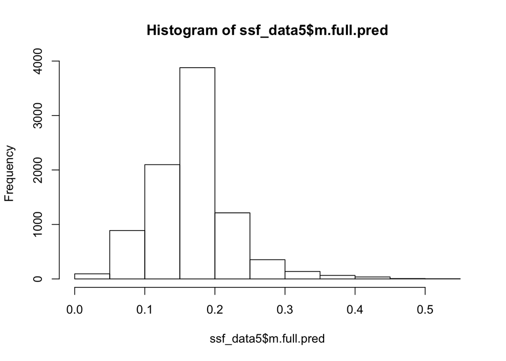

```r
ssf_data5$m.full.pred <- predict(m.full, type="expected")
hist(ssf_data5$m.full.pred)
```

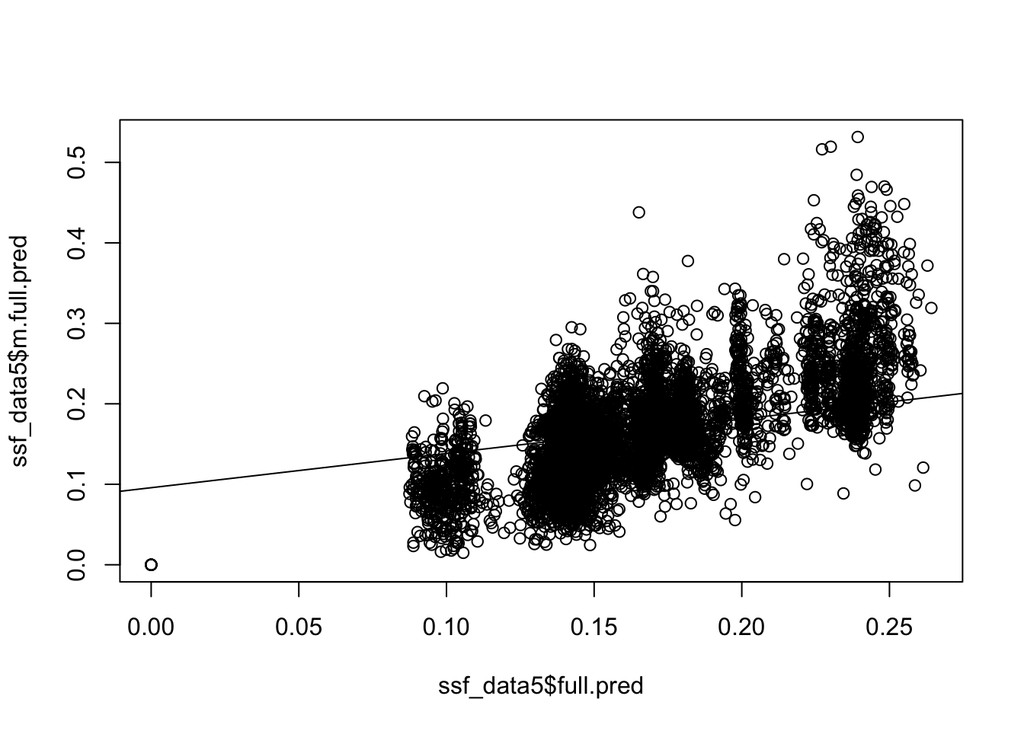

```r
ssf_data5$full.pred <- predict(full, type="response")

plot(ssf_data5$full.pred, ssf_data5$m.full.pred)
abline(lm(ssf_data5$full.pred~ ssf_data5$m.full.pred))
```

```r
cor(ssf_data5$full.pred, ssf_data5$m.full.pred)
```

```
## [1] 0.6531797
```

#### Discussion: what to make of the different interpretations of Clogit versus Logit for the same dataset?

#### Objective 4.2 Model Selection for cLogit Models

```r
#### MOdel Selection for cLogit Models

## fit null model
m.null  <- clogit(used ~ strata(stratum), data = ssf_data5)
#summary(m.null) # note if you try to look at this model you get this error message
# Error in print.coxph(x) : Input is not valid - I've supressed this error message.

#AIC(m.full, m.landcov, m.disthha, m.distha, m.elev, m.null)
# Also, note if you do this command you also get an error
#             df      AIC
#   m.full    16 5273.703
#   m.landcov 13 5267.965
#   m.disthha  1 5248.272
#   m.distha   1 5248.271
#   m.elev     1 5248.230
#   m.null     0       NA
#   Warning message:
#   In is.na(coefficients(object)) :
#     is.na() applied to non-(list or vector) of type 'NULL'
AIC(m.full, m.landcov, m.disthha, m.distha, m.elev)
```

```
##           df      AIC
## m.full    17 5102.048
## m.landcov 14 5118.282
## m.disthha  1 5224.344
## m.distha   1 5223.065
## m.elev     1 5215.002
```

```r
#stepAIC(m.full, direction = "backward")
# Also, note if you do this command you also get an error

## So - you cannot fit models with 0 parameters in Coxph model!!!!!

#AIC(m.full, m.landcov, m.disthha, m.distha, m.elev, full)
#Warning message:
#In AIC.default(m.full, m.landcov, m.disthha, m.distha, m.elev, full) :
#  models are not all fitted to the same number of observations
## note you get an error message, cannot compare to the Naive Logit model for 2 reasons
## 1) differnet # of data points (why?)
## 2) different calculation of the log-likelihood - confiditonal likelihood vs. maximum likelihood. apples and oranges.
## Cannot solve whether or not to add conditioning based on AIC.

  # But you can compare within mclogit models
AIC(m.full, m.landcov, m.disthha, m.distha, m.elev)
```

```
##           df      AIC
## m.full    17 5102.048
## m.landcov 14 5118.282
## m.disthha  1 5224.344
## m.distha   1 5223.065
## m.elev     1 5215.002
```

#### Objective 5.0 Matched-case control over multiple individual - Mixed-effects Clogit

##### 1) Here are the first 2 papers that figured out how to add a random intercept for each individual animal (e.g.), however, it did so in MATLAB. So, its mostly inaccessible to biologists.

### Craiu, R. V., T. Duchesne, D. Fortin, and S. Baillargeon. 2011. Conditional Logistic Regression With Longitudinal Follow-up and Individual-Level Random Coefficients: A Stable and Efficient Two-Step Estimation Method. Journal of Computational and Graphical Statistics 20:767-784.

### Duchesne, T., D. Fortin, and N. Courbin. 2010. Mixed conditional logistic regression for habitat selection studies. Journal of Animal Ecology 79:548-555.

```r
#install.packages(c("coxme", "mclogit")) ## note these are already installed above.
#library(coxme)
#library(mclogit)
##### Bring in Bison dataset
```

##### This data set was collected in order to study habitat selection by groups of free-ranging bison. For each observed group, two individuals (dyad) equipped with GPS radio-collars were followed simultaneously. A cluster is defined here as a pair of bison. This data set contains 20 clusters. The number of strata per cluster varies between 13 and 345 for a total of 1410 strata. A stratum is composed of two visited GPS locations (one for each individual) gathered at the same time, together with 10 random locations (five drawn within 700 m of each of the two focal bison). Therefore, there are 12 observations per stratum, with 2 cases (Y=1) and 10 controls (Y=0). However, due to problems in the data collection, 17 of the 1410 strata have only 6 observations (1 case and 5 controls).

##### To make things simpler, consider that the two bison are a single calf:cow pair and so not independent, and thus similar to our elk data.

# install.packages(“TwoStepCLogit”) ## note these are already installed above.

# library(TwoStepCLogit)#### t

```r
head(bison)
```

```
##   Cluster Strata Y water agric forest meadow   biomass   pmeadow
## 1       1      1 1     0     0      0      1 0.4995933 0.1473661
## 2       1      1 0     0     0      1      0 0.0000000 0.1642693
## 3       1      1 0     0     0      1      0 0.0000000 0.1360807
## 4       1      1 0     0     0      1      0 0.0000000 0.1339337
## 5       1      1 0     0     0      1      0 0.0000000 0.1622879
## 6       1      1 0     0     0      1      0 0.0000000 0.1669558
```

```r
str(bison)
```

```
## 'data.frame':    16818 obs. of  9 variables:
##  $ Cluster: int  1 1 1 1 1 1 1 1 1 1 ...
##  $ Strata : int  1 1 1 1 1 1 1 1 1 1 ...
##  $ Y      : int  1 0 0 0 0 0 1 0 0 0 ...
##  $ water  : int  0 0 0 0 0 0 0 0 0 0 ...
##  $ agric  : int  0 0 0 0 0 0 0 0 0 0 ...
##  $ forest : int  0 1 1 1 1 1 0 1 1 1 ...
##  $ meadow : int  1 0 0 0 0 0 1 0 0 0 ...
##  $ biomass: num  0.5 0 0 0 0 ...
##  $ pmeadow: num  0.147 0.164 0.136 0.134 0.162 ...
```

```r
head(table(bison$Strata,bison$Cluster))
```

```
##
##      1  2  3  4  5  6  7  8  9 10 11 12 13 14 15 16 17 18 19 20
##   1 12 12 12 12 12 12 12 12 12 12 12 12 12 12 12 12 12 12 12 12
##   2 12 12 12 12 12 12 12 12 12 12 12 12 12 12 12 12 12 12 12 12
##   3 12 12 12 12 12 12 12 12 12 12 12 12 12 12 12 12 12 12 12 12
##   4 12 12 12 12 12 12 12 12 12 12 12 12 12 12 12 12 12 12 12 12
##   5 12 12 12 12 12 12 12 12 12 12 12 12 12 12 12 12 12 12 12 12
##   6 12 12 12 12 12 12 12 12 12 12 12 12 12 12 12 12 12 12 12 12
```

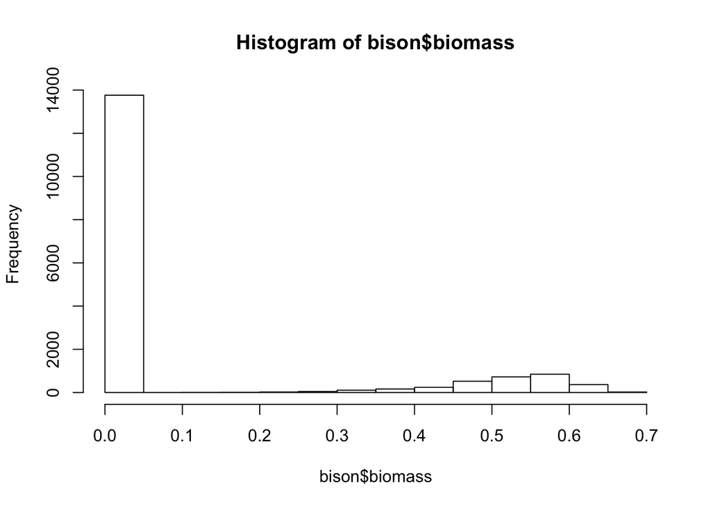

```r
hist(bison$biomass)
```

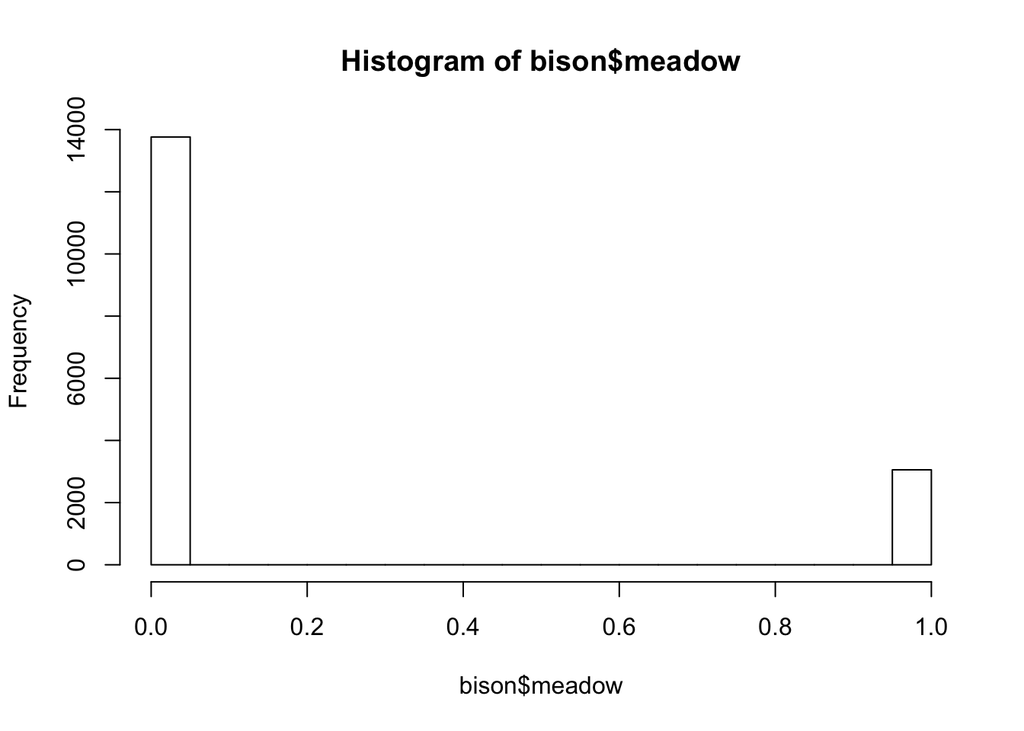

```r
hist(bison$meadow)
```

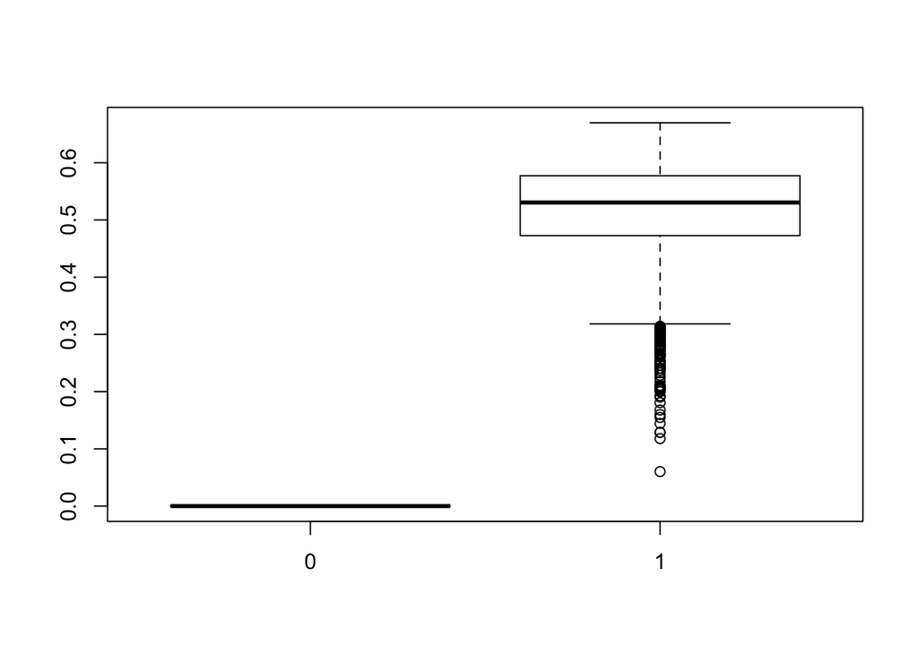

```r
boxplot(bison$biomass~ bison$meadow)
```

```r
bison.mcclogit <- mclogit(cbind(Y, Strata) ~pmeadow + biomass, random ~1|Cluster, data=bison)
```

```
##
## Iteration 1 - Deviance = 8679.067
## Iteration 2 - Deviance = 8602.081
## Iteration 3 - Deviance = 8602.068
## Iteration 4 - Deviance = 8602.068
##
## Initial estimate of theta:  0.0002237255
## Iteration 1 - Deviance = 8601.149 criterion =  0.0001068809
## Iteration 2 - Deviance = 8601.149 criterion =  2.462467e-09
```

```r
summary(bison.mcclogit)
```

```
##
## Call:
## mclogit(formula = cbind(Y, Strata) ~ pmeadow + biomass, data = bison,
##     random = random ~ 1 | Cluster)
##
##                Estimate Std. Error z value Pr(>|z|)
## pmeadow      -4.3189211  0.3958012 -10.912   <2e-16 ***
## biomass       2.8470315  0.0733214  38.829   <2e-16 ***
## Var(Cluster)  0.0002491  0.0002619   0.127    0.899
## ---
## Signif. codes:  0 '***' 0.001 '**' 0.01 '*' 0.05 '.' 0.1 ' ' 1
##
## Null Deviance:     10040
## Residual Deviance: 8601
## Number of Fisher Scoring iterations:  2
## Number of observations:  2803
```

```r
bison.mcfixed <- mclogit(cbind(Y, Strata) ~pmeadow + biomass, data=bison)
```

```
##
## Iteration 1 - Deviance = 8679.067
## Iteration 2 - Deviance = 8602.081
## Iteration 3 - Deviance = 8602.068
## Iteration 4 - Deviance = 8602.068
```

```r
summary(bison.mcfixed)
```

```
##
## Call:
## mclogit(formula = cbind(Y, Strata) ~ pmeadow + biomass, data = bison)
##
##         Estimate Std. Error z value Pr(>|z|)
## pmeadow  -4.3268     0.3955  -10.94   <2e-16 ***
## biomass   2.8457     0.0733   38.83   <2e-16 ***
## ---
## Signif. codes:  0 '***' 0.001 '**' 0.01 '*' 0.05 '.' 0.1 ' ' 1
##
## Null Deviance:     10040
## Residual Deviance: 8602
## Number of Fisher Scoring iterations:  4
## Number of observations:  2803
```

```r
bison.naive <- glm(Y ~ pmeadow + biomass, data = bison, family = binomial(logit))
summary(bison.naive)
```

```
##
## Call:
## glm(formula = Y ~ pmeadow + biomass, family = binomial(logit),
##     data = bison)
##
## Deviance Residuals:
##     Min       1Q   Median       3Q      Max
## -1.3800  -0.4933  -0.4520  -0.4450   2.8033
##
## Coefficients:
##             Estimate Std. Error z value Pr(>|z|)
## (Intercept) -1.08494    0.07507  -14.45   <2e-16 ***
## pmeadow     -7.05399    0.49137  -14.36   <2e-16 ***
## biomass      3.77953    0.09011   41.94   <2e-16 ***
## ---
## Signif. codes:  0 '***' 0.001 '**' 0.01 '*' 0.05 '.' 0.1 ' ' 1
##
## (Dispersion parameter for binomial family taken to be 1)
##
##     Null deviance: 15155  on 16817  degrees of freedom
## Residual deviance: 13312  on 16815  degrees of freedom
## AIC: 13318
##
## Number of Fisher Scoring iterations: 4
```

##### So here, there really isnt that much different between the two mclogit models with or without a random effect for each bison ID (Cluster). In both situations, the Beta coefficient for biomass and pmeadow were fairly similar, about -4.3 for pmeadow and 2.85 for biomass in both models. However, the coefficients differed quite a bit from the naive logistic regression model that showed much stronger avoidance of meadows and selection for high biomass, assuming that everything was available at the same time to each animal.

##### Now we can consider model selection between the two mclogit models, remember, that we can’t compare mclogit to logit.

```r
AIC(bison.mcclogit, bison.mcfixed)
```

```
##                df      AIC
## bison.mcclogit  3 8607.149
## bison.mcfixed   2 8606.068
```

```r
AIC(bison.naive)
```

```
## [1] 13317.71
```

```r
#### Note that the AIC's are not comparable!!
```

##### And finally, we compare the different predictions between the mcclogit model and the logit model.

```r
bison$mcclogit <- predict(bison.mcclogit, response="expected")
bison$mcfixed <- predict(bison.mcfixed, response="expected")
bison$naive <- predict(bison.naive, type="response")
str(bison)
```

```
## 'data.frame':    16818 obs. of  12 variables:
##  $ Cluster : int  1 1 1 1 1 1 1 1 1 1 ...
##  $ Strata  : int  1 1 1 1 1 1 1 1 1 1 ...
##  $ Y       : int  1 0 0 0 0 0 1 0 0 0 ...
##  $ water   : int  0 0 0 0 0 0 0 0 0 0 ...
##  $ agric   : int  0 0 0 0 0 0 0 0 0 0 ...
##  $ forest  : int  0 1 1 1 1 1 0 1 1 1 ...
##  $ meadow  : int  1 0 0 0 0 0 1 0 0 0 ...
##  $ biomass : num  0.5 0 0 0 0 ...
##  $ pmeadow : num  0.147 0.164 0.136 0.134 0.162 ...
##  $ mcclogit: num  0.786 -0.709 -0.588 -0.578 -0.701 ...
##  $ mcfixed : num  0.784 -0.711 -0.589 -0.58 -0.702 ...
##  $ naive   : num  0.4412 0.0959 0.1146 0.1161 0.0971 ...
```

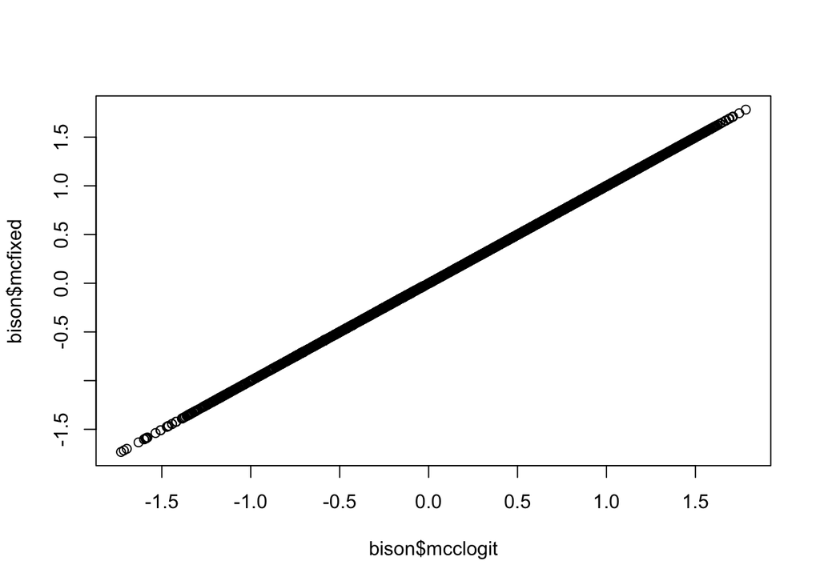

```r
plot(bison$mcclogit, bison$mcfixed)
```

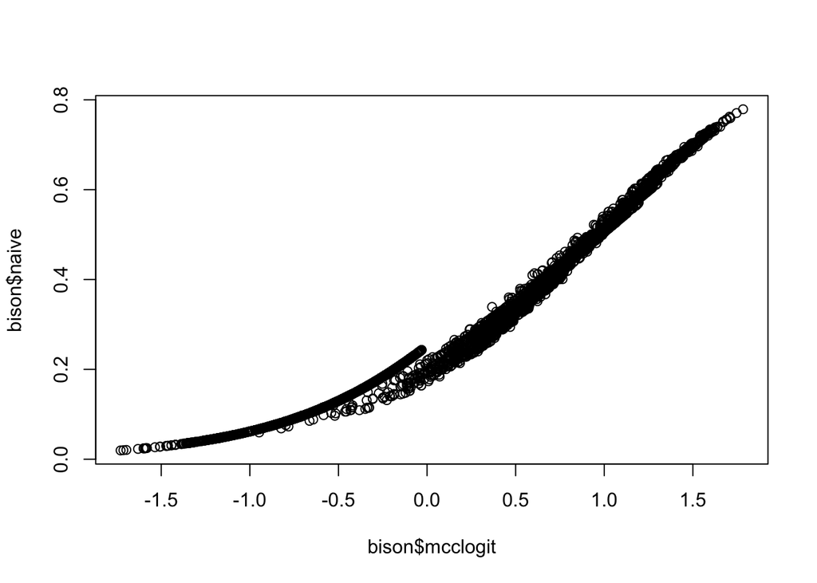

```r
plot(bison$mcclogit, bison$naive)
```

##### And again, notice that we are really talking about different probabilities when we are comparing the clogit model to the naive logistic regression model predictions. In this dataset, the differences between the individual bison were not that impressive, so a random effect for individual bison was probably not that necessary. But there is still a big difference in interpretation between clogit and logit.